# Disconnected Landlords PSM Analysis

Dmytro Kunchenko

2025-06-04

# Overview

This document outlines the Propensity Score Matching (PSM) analysis conducted for the “Disconnected Landlords” project. It includes data loading, cleaning, treatment definitions, matching procedures, balance diagnostics, and regression analyses. This version has been refactored to improve conciseness and reduce code duplication by splitting the main analysis function.

# Data Loading and Preprocessing

## Load Data

First, load the dataset. **Ensure the path to the .RData file is correct.**

```r
# Load data
# Replace with the correct path if necessary
load_path <- "~/disconnected-landlords-project/EPC_matched_combined.RData"
# For testing, if the file doesn't exist, create a dummy EPC_matched_combined
if (!file.exists(load_path)) {
  warning(paste("Data file not found at:", load_path, ". Using a minimal dummy dataset for demonstration."))
  EPC_matched_combined <- data.table(
    UPRN = 1:1000,
    MAIN_FUEL = sample(c("mains gas", "electricity", "oil", "Gas: mains gas", "INVALID!", "", "To be used only when other fuel specified"), 1000, replace = TRUE),
    country_incorporated_1 = sample(c("UNITED KINGDOM", "JERSEY", "USA"), 1000, replace = TRUE),
    coarse_proprietorship = sample(c("For-Profit", "Non-Profit", "Public Sector", "Individual"), 1000, replace = TRUE),
    country_incorporated_tax_haven = sample(c(0, 1, NA), 1000, replace = TRUE, prob = c(0.7, 0.2, 0.1)),
    tenure = sample(c("Freehold", "Leasehold", NA), 1000, replace = TRUE),
    CONSTRUCTION_AGE_BAND = sample(c("2000-Present", "1950-1975", "Pre-1900", NA), 1000, replace = TRUE),
    PROPERTY_TYPE = sample(c("House", "Flat", "Bungalow", NA), 1000, replace = TRUE),
    BUILT_FORM = sample(c("Detached", "Semi-Detached", "Terraced", "End-Terrace", NA), 1000, replace = TRUE),
    TOTAL_FLOOR_AREA = rnorm(1000, 100, 20),
    NUMBER_HABITABLE_ROOMS = rpois(1000, 5),
    lodgement_year = sample(2010:2023, 1000, replace = TRUE),
    bad_EPC = sample(0:1, 1000, replace = TRUE),
    source = "Dummy",
    postcode_sector = sample(paste0("AB", 1:10), 1000, replace = TRUE),
    LOCAL_AUTHORITY_LABEL = sample(paste0("LA_", LETTERS[1:5]), 1000, replace = TRUE)
  )
} else {
  load(load_path)
}

# Ensure EPC_matched_combined is a data.table
if (!is.data.table(EPC_matched_combined)) {
  setDT(EPC_matched_combined)
}
# Display a brief summary of the loaded data
print(head(EPC_matched_combined, 3))
```

[output not shown]

[output cut: 176 more lines]

[output not shown]

```r
cat("\nDimensions of loaded data:", dim(EPC_matched_combined), "\n")
```

```
##
## Dimensions of loaded data: 1857191 141
```

## Clean `MAIN_FUEL` Variable

The `MAIN_FUEL` variable requires cleaning and standardization.

```
##
## Frequency table for MAIN_FUEL_FINAL (including NAs):
```

```
##
##     biomass        coal   dual_fuel electricity heating_oil         lpg
##         732        1952           3      245697       43091       12893
##   mains_gas        wood        <NA>
##     1435064        4138      113621
```

# Treatment Definitions

The treatments are combinations of coarse proprietorship (for-profit, non-profit, public) and registration country of the landlord.

Following treatments are proposed: (1) UK for-profit firms `treat_uk_forprofit`; (2) non-UK for-profit firms `treat_foreign_forprofit`; (3) tax haven registred entities, regardless whether for or not-for profit `treat_tax_haven`; (4) UK public sector `treat_uk_public`; (5) [unused] all for-profit firms `treat_all_forprofit`.

NOTE: I am somewhat surprised that the overwhelming majority of foreign owners are registered (at least partially) in tax havens - since for a property to have a “tax haven” flag, at least one of its proprietors must be in a tax haven.

```r
# Treatment definition 1 - UK For-Profits
EPC_matched_combined[, treat_uk_forprofit
  := as.integer(grepl("UNITED KINGDOM", country_incorporated_1, ignore.case = TRUE) &
  grepl("For-Profit", coarse_proprietorship, ignore.case = TRUE))]

# Treatment definition 2 - Non - UK For-Profits
EPC_matched_combined[, treat_foreign_forprofit := as.integer(
  grepl("For-Profit", coarse_proprietorship, ignore.case = TRUE) &
  !grepl("UNITED KINGDOM", country_incorporated_1, ignore.case = TRUE)
)]

# Treatment definition 3 - Tax Haven
EPC_matched_combined[, treat_tax_haven := as.integer(country_incorporated_tax_haven == 1)]

# Treatment definition 4 - UK Public Sector
EPC_matched_combined[, treat_uk_public
  := as.integer(grepl("Public Sector", coarse_proprietorship, ignore.case = TRUE))]

# Treatment definition 5 - All For Profit
EPC_matched_combined[, treat_all_forprofit
  := as.integer(grepl("For-Profit", coarse_proprietorship, ignore.case = TRUE))]

cat("Summary of treatment variables:\n")
```

```
## Summary of treatment variables:
```

```r
print(summary(EPC_matched_combined[, .(treat_uk_forprofit, treat_foreign_forprofit, treat_tax_haven, treat_uk_public, treat_all_forprofit)]))
```

```
##  treat_uk_forprofit treat_foreign_forprofit treat_tax_haven   treat_uk_public
##  Min.   :0.0000     Min.   :0.00000         Min.   :0.00000   Min.   :0.00000
##  1st Qu.:0.0000     1st Qu.:0.00000         1st Qu.:0.00000   1st Qu.:0.00000
##  Median :0.0000     Median :0.00000         Median :0.00000   Median :0.00000
##  Mean   :0.2067     Mean   :0.01936         Mean   :0.01966   Mean   :0.08679
##  3rd Qu.:0.0000     3rd Qu.:0.00000         3rd Qu.:0.00000   3rd Qu.:0.00000
##  Max.   :1.0000     Max.   :1.00000         Max.   :1.00000   Max.   :1.00000
##  treat_all_forprofit
##  Min.   :0.0000
##  1st Qu.:0.0000
##  Median :0.0000
##  Mean   :0.2261
##  3rd Qu.:0.0000
##  Max.   :1.0000
```

```
## Cross-tabulation: Tax Haven Status vs Coarse Proprietorship
```

```
##
##     For-Profit Non-Profit/Community Organisations Public Sector    <NA>
##   0     384453                             251853        161188 1023189
##   1      35414                               1094             0       0
```

# Matching Procedure

Propensity score and exact matching variables are taken from “Regulatory barriers to climate action: evidence from conservation areas in England”: Exact matching on `tenure` (leasehold/freehold), construction age band, property type, built form (detached/semi-detached/…), main fuel (see note 1 and code above). Propensity score matching (here: nearest neighbour / quick/ but could be others - see note 2) is preformed on total floor area, number of habitable rooms and EPC certificate lodgement year.

The matching is performed within local authorities, and then the lists get amalgamated together. The local authorities with less than 5 treated or 15 control observations should be skipped. In the end, when regressions are ran, for the benefit of allowing matched-pair fixed effects, the `subclass` variable, created by `matchit` as an index of the matched pair is concatenated with the local authority ID from the EPC dataset, so we actually get unique matched pairs (with two observations within each concatenated ID, as expected).

The output for each treatment variable includes: the code for the matching, matching balance assesment using a balance table and a love plot, the regression of the relevant treatment on bad_EPC with matched pair fixed effects.

NOTE 1 : The `FUEL_TYPE` variable, even coarsened as above, significantly reduces the size of the treated cohort. This becomes a more significant problem with matching for foreign for-profit companies later on – leaving just dozens of treated observation in some cases.

NOTE 2: The sections of the code for other matching methods can be commented-uncommented as necessary, the matching evaluation code (tables / plots) should work fine. See comments in code. TODO: A more elegant functional programming approach would avoid duplicating all the code everything.

# Defining Functions

```r
# Function to perform matching
perform_matching <- function(input_dt,
                             treatment_var,
                             analysis_id,
                             prop_score_covs,
                             exact_vars,
                             subset_condition_expr = NULL,
                             outcome_var = "bad_EPC", # Keep for consistency, though not used directly in matching
                             min_treated_la = 5,
                             min_control_la = 15,
                             verbose = FALSE) {

  cat(paste0("\n--- Performing Matching for: ", analysis_id, " ---\n"))

  # Apply subset condition if provided
  if (!is.null(subset_condition_expr)) {
    current_data <- input_dt[eval(subset_condition_expr)]
    cat(paste0("Subset applied for ", analysis_id, ". Rows after subset: ", nrow(current_data), "\n"))
  } else {
    current_data <- copy(input_dt)
  }

  all_nec_vars <- c("source", outcome_var, treatment_var, prop_score_covs, exact_vars, "postcode_sector", "LOCAL_AUTHORITY_LABEL")

  missing_cols <- setdiff(all_nec_vars, names(current_data))
  if (length(missing_cols) > 0) {
    stop(paste("Missing columns for analysis", analysis_id, ":", paste(missing_cols, collapse=", ")))
  }

  combined_nomiss <- current_data[complete.cases(current_data[, ..all_nec_vars])]

  if (nrow(combined_nomiss) == 0) {
    cat("No complete cases for matching in analysis:", analysis_id, "\nSkipping matching.\n")
    return(list(mdata_nearest = data.table(), mdata_quick = data.table(), combined_nomiss = data.table()))
  }

  for (col in exact_vars) {
    if (!is.factor(combined_nomiss[[col]])) {
      combined_nomiss[, (col) := as.factor(get(col))]
    }
  }

  unique_las <- unique(combined_nomiss$LOCAL_AUTHORITY_LABEL)
  mdata_list_nearest <- list()
  mdata_list_quick <- list()

  for (la in unique_las) {
    la_data <- combined_nomiss[LOCAL_AUTHORITY_LABEL == la]
    if (verbose) cat("\nProcessing LA:", la, "- Total rows:", nrow(la_data), "\n")

    n_treated <- sum(la_data[[treatment_var]] == 1, na.rm = TRUE)
    n_control <- sum(la_data[[treatment_var]] == 0, na.rm = TRUE)
    if (verbose) cat("Treated units:", n_treated, "Control units:", n_control, "\n")

    if (n_treated < min_treated_la || n_control < min_control_la) {
      if (verbose) cat("Skipping LA", la, "due to insufficient treated/control units.\n")
      next
    }

    ps_formula_str <- paste(treatment_var, "~", paste(prop_score_covs, collapse = " + "))
    ps_formula <- as.formula(ps_formula_str)
    exact_formula_str <- paste("~", paste(exact_vars, collapse = " + "))
    exact_formula_la <- as.formula(exact_formula_str)

    tryCatch({
      match_obj_nearest <- matchit(ps_formula, data = la_data, method = "nearest",
                                   distance = "glm", exact = exact_formula_la)
      mdata_list_nearest[[la]] <- match.data(match_obj_nearest)
    }, error = function(e) cat("Error Nearest matching LA:", la, "-", e$message, "\n"))

    tryCatch({
      match_obj_quick <- matchit(ps_formula, data = la_data, method = "quick",
                                 exact = exact_formula_la)
      mdata_list_quick[[la]] <- match.data(match_obj_quick)
    }, error = function(e) cat("Error Quick matching LA:", la, "-", e$message, "\n"))
  }

  mdata_llc_nearest_by_la <- rbindlist(mdata_list_nearest, use.names = TRUE, fill = TRUE, idcol = "original_LA_for_debug")
  mdata_llc_quick_by_la <- rbindlist(mdata_list_quick, use.names = TRUE, fill = TRUE, idcol = "original_LA_for_debug")

  cat(paste0("Matching complete for ", analysis_id, ". Nearest matched N=", nrow(mdata_llc_nearest_by_la), ", Quick matched N=", nrow(mdata_llc_quick_by_la),"\n"))

  return(list(
    mdata_nearest = mdata_llc_nearest_by_la,
    mdata_quick = mdata_llc_quick_by_la,
    combined_nomiss = combined_nomiss # This is the pre-matching data used for this specific analysis (subsetted if applicable)
  ))
}

# Function to generate balance tables
generate_balance_tables <- function(matching_output,
                                    treatment_var,
                                    analysis_id,
                                    prop_score_covs,
                                    exact_vars) {

  cat(paste0("\n## Balance Assessment Tables for ", analysis_id, "\n"))

  mdata_nearest <- matching_output$mdata_nearest
  mdata_quick <- matching_output$mdata_quick
  combined_nomiss_for_analysis <- matching_output$combined_nomiss # Use the combined_nomiss specific to this analysis

  balance_formula_terms <- c(prop_score_covs, sapply(exact_vars, function(v) paste0("factor(", v, ")")))
  balance_formula_str <- paste(treatment_var, "~", paste(balance_formula_terms, collapse = " + "))
  balance_formula <- as.formula(balance_formula_str)

  bal_tabs <- list()

  # Unadjusted/Baseline
  if (nrow(combined_nomiss_for_analysis) > 0) {
    tryCatch({
      bal_tabs$Unadjusted <- bal.tab(balance_formula, data = combined_nomiss_for_analysis,
                                     treat = treatment_var,
                                     s.d.denom = "pooled", binary = "std", disp.means = TRUE)
      cat("\n### Balance Table: Unadjusted\n")
      balance_df_unadj <- as.data.frame(bal_tabs$Unadjusted$Balance)
      if (nrow(balance_df_unadj) > 0) {
          print(knitr::kable(balance_df_unadj, caption = paste(analysis_id, ": Balance - Unadjusted"), digits = 3) %>%
                kable_styling(bootstrap_options = c("striped", "hover", "condensed"), full_width = FALSE))
          if (!is.null(bal_tabs$Unadjusted$Observations)) {
             cat("\n#### Observations (Unadjusted):\n")
             print(knitr::kable(bal_tabs$Unadjusted$Observations))
          }
      } else { cat("No balance info for Unadjusted.\n")}
    }, error = function(e) cat("Error bal.tab Unadjusted:", e$message, "\n"))
  } else { cat("No data for Unadjusted balance table in", analysis_id, "\n")}

  # Nearest neighbor
  if (nrow(mdata_nearest) > 0) {
    tryCatch({
      bal_tabs$Nearest <- bal.tab(balance_formula, data = mdata_nearest,
                                  weights = "weights", method = "matching",
                                  s.d.denom = "pooled", un = TRUE, binary = "std", disp.matched = TRUE, disp.means = TRUE)
      cat("\n### Balance Table: Nearest Neighbor Matching\n")
      balance_df_nearest <- as.data.frame(bal_tabs$Nearest$Balance)
      if (nrow(balance_df_nearest) > 0) {
          print(knitr::kable(balance_df_nearest, caption = paste(analysis_id, ": Balance - Nearest Neighbor"), digits = 3) %>%
                kable_styling(bootstrap_options = c("striped", "hover", "condensed"), full_width = FALSE))
          if (!is.null(bal_tabs$Nearest$Observations)) {
             cat("\n#### Observations (Nearest Neighbor):\n")
             print(knitr::kable(bal_tabs$Nearest$Observations))
          }
      } else { cat("No balance info for Nearest.\n")}
    }, error = function(e) cat("Error bal.tab Nearest:", e$message, "\n"))
  } else { cat("No data for Nearest Neighbor balance table in", analysis_id, "\n")}

  # Quick matching
  if (nrow(mdata_quick) > 0) {
    tryCatch({
      bal_tabs$Quick <- bal.tab(balance_formula, data = mdata_quick,
                                weights = "weights", method = "matching",
                                s.d.denom = "pooled", un = TRUE, binary = "std", disp.matched = TRUE, disp.means = TRUE)
      cat("\n### Balance Table: Quick Matching\n")
      balance_df_quick <- as.data.frame(bal_tabs$Quick$Balance)
       if (nrow(balance_df_quick) > 0) {
          print(knitr::kable(balance_df_quick, caption = paste(analysis_id, ": Balance - Quick Matching"), digits = 3) %>%
                kable_styling(bootstrap_options = c("striped", "hover", "condensed"), full_width = FALSE))
          if (!is.null(bal_tabs$Quick$Observations)) {
             cat("\n#### Observations (Quick Matching):\n")
             print(knitr::kable(bal_tabs$Quick$Observations))
          }
      } else { cat("No balance info for Quick.\n")}
    }, error = function(e) cat("Error bal.tab Quick:", e$message, "\n"))
  } else { cat("No data for Quick Matching balance table in", analysis_id, "\n")}

  return(bal_tabs)
}

# Function to generate Love plots
generate_love_plots <- function(bal_tabs_list, analysis_id) {
  cat(paste0("\n## Love Plots for ", analysis_id, "\n"))

  if (!is.null(bal_tabs_list$Quick) && length(bal_tabs_list$Quick) > 0) {
    tryCatch({
      lpq <- love.plot(bal_tabs_list$Quick, threshold = .1, abs = TRUE, line = TRUE, stars = "std",
                       title = paste(analysis_id, ": Covariate Balance (Quick Matching)"), var.order = "unadjusted")
      print(lpq)
    }, error = function(e) cat("Error generating Love Plot (Quick) for", analysis_id, ":", e$message, "\n"))
  } else { cat("Quick matching balance data not available for Love Plot in", analysis_id, ".\n") }

  if (!is.null(bal_tabs_list$Nearest) && length(bal_tabs_list$Nearest) > 0) {
     tryCatch({
        lpn <- love.plot(bal_tabs_list$Nearest, threshold = .1, abs = TRUE, line = TRUE, stars = "std",
                         title = paste(analysis_id, ": Covariate Balance (Nearest Neighbor)"), var.order = "unadjusted")
        print(lpn)
     }, error = function(e) cat("Error generating Love Plot (Nearest) for", analysis_id, ":", e$message, "\n"))
  } else { cat("Nearest Neighbor matching balance data not available for Love Plot in", analysis_id, ".\n") }
}

# Define common variables for PSM
common_exact_vars <- c("tenure", "CONSTRUCTION_AGE_BAND", "PROPERTY_TYPE", "BUILT_FORM", "MAIN_FUEL_FINAL")
common_prop_score_covs <- c("TOTAL_FLOOR_AREA", "NUMBER_HABITABLE_ROOMS", "lodgement_year")
outcome_variable <- "bad_EPC"
```

# PSM Analysis 1: UK For-Profits (`treat_uk_forprofit`)

Treatment: UK for profit; Control: Otherwise

— Performing Matching for: PSM1_UK_ForProfit — Matching complete for PSM1_UK_ForProfit. Nearest matched N=278876, Quick matched N=618192

## Balance Assessment Tables for PSM1_UK_ForProfit

### Balance Table: Unadjusted

PSM1_UK_ForProfit : Balance - Unadjusted

|  | Type | M.0.Un | M.1.Un | Diff.Un | M.0.Adj | M.1.Adj | Diff.Adj |
| --- | --- | --- | --- | --- | --- | --- | --- |
| TOTAL_FLOOR_AREA | Contin. | 87.293 | 70.750 | -0.233 | NA | NA | NA |
| NUMBER_HABITABLE_ROOMS | Contin. | 4.169 | 3.190 | -0.606 | NA | NA | NA |
| lodgement_year | Contin. | 2016.841 | 2017.304 | 0.098 | NA | NA | NA |
| factor(tenure)_Freehold | Binary | 0.268 | 0.814 | 1.309 | NA | NA | NA |
| factor(tenure)_Leasehold | Binary | 0.023 | 0.186 | 0.551 | NA | NA | NA |
| factor(tenure)_Not in OCOD, CCOD | Binary | 0.708 | 0.000 | -2.204 | NA | NA | NA |
| factor(CONSTRUCTION_AGE_BAND)_ | Binary | 0.003 | 0.003 | 0.000 | NA | NA | NA |
| factor(CONSTRUCTION_AGE_BAND)_England and Wales: 1900-1929 | Binary | 0.192 | 0.186 | -0.016 | NA | NA | NA |
| factor(CONSTRUCTION_AGE_BAND)_England and Wales: 1930-1949 | Binary | 0.133 | 0.101 | -0.100 | NA | NA | NA |
| factor(CONSTRUCTION_AGE_BAND)_England and Wales: 1950-1966 | Binary | 0.180 | 0.085 | -0.283 | NA | NA | NA |
| factor(CONSTRUCTION_AGE_BAND)_England and Wales: 1967-1975 | Binary | 0.120 | 0.077 | -0.144 | NA | NA | NA |
| factor(CONSTRUCTION_AGE_BAND)_England and Wales: 1976-1982 | Binary | 0.055 | 0.040 | -0.073 | NA | NA | NA |
| factor(CONSTRUCTION_AGE_BAND)_England and Wales: 1983-1990 | Binary | 0.054 | 0.076 | 0.090 | NA | NA | NA |
| factor(CONSTRUCTION_AGE_BAND)_England and Wales: 1991-1995 | Binary | 0.033 | 0.045 | 0.063 | NA | NA | NA |
| factor(CONSTRUCTION_AGE_BAND)_England and Wales: 1996-2002 | Binary | 0.041 | 0.082 | 0.170 | NA | NA | NA |
| factor(CONSTRUCTION_AGE_BAND)_England and Wales: 2003-2006 | Binary | 0.031 | 0.097 | 0.274 | NA | NA | NA |
| factor(CONSTRUCTION_AGE_BAND)_England and Wales: 2007-2011 | Binary | 0.011 | 0.040 | 0.186 | NA | NA | NA |
| factor(CONSTRUCTION_AGE_BAND)_England and Wales: 2007 onwards | Binary | 0.014 | 0.037 | 0.150 | NA | NA | NA |
| factor(CONSTRUCTION_AGE_BAND)_England and Wales: 2012 onwards | Binary | 0.006 | 0.014 | 0.085 | NA | NA | NA |
| factor(CONSTRUCTION_AGE_BAND)_England and Wales: before 1900 | Binary | 0.126 | 0.114 | -0.036 | NA | NA | NA |
| factor(CONSTRUCTION_AGE_BAND)_INVALID! | Binary | 0.002 | 0.003 | 0.015 | NA | NA | NA |
| factor(PROPERTY_TYPE)_Bungalow | Binary | 0.088 | 0.018 | -0.316 | NA | NA | NA |
| factor(PROPERTY_TYPE)_Flat | Binary | 0.312 | 0.765 | 1.019 | NA | NA | NA |
| factor(PROPERTY_TYPE)_House | Binary | 0.566 | 0.163 | -0.920 | NA | NA | NA |
| factor(PROPERTY_TYPE)_Maisonette | Binary | 0.033 | 0.053 | 0.096 | NA | NA | NA |
| factor(PROPERTY_TYPE)_Park home | Binary | 0.000 | 0.001 | 0.024 | NA | NA | NA |
| factor(BUILT_FORM)_Detached | Binary | 0.199 | 0.084 | -0.334 | NA | NA | NA |
| factor(BUILT_FORM)_Enclosed End-Terrace | Binary | 0.015 | 0.051 | 0.202 | NA | NA | NA |
| factor(BUILT_FORM)_Enclosed Mid-Terrace | Binary | 0.013 | 0.046 | 0.194 | NA | NA | NA |
| factor(BUILT_FORM)_End-Terrace | Binary | 0.149 | 0.172 | 0.063 | NA | NA | NA |
| factor(BUILT_FORM)_Mid-Terrace | Binary | 0.357 | 0.430 | 0.151 | NA | NA | NA |
| factor(BUILT_FORM)_NO DATA! | Binary | 0.008 | 0.018 | 0.091 | NA | NA | NA |
| factor(BUILT_FORM)_Semi-Detached | Binary | 0.259 | 0.198 | -0.146 | NA | NA | NA |
| factor(MAIN_FUEL_FINAL)_biomass | Binary | 0.000 | 0.001 | 0.011 | NA | NA | NA |
| factor(MAIN_FUEL_FINAL)_coal | Binary | 0.001 | 0.001 | -0.029 | NA | NA | NA |
| factor(MAIN_FUEL_FINAL)_dual_fuel | Binary | 0.000 | 0.000 | 0.001 | NA | NA | NA |
| factor(MAIN_FUEL_FINAL)_electricity | Binary | 0.096 | 0.305 | 0.542 | NA | NA | NA |
| factor(MAIN_FUEL_FINAL)_heating_oil | Binary | 0.031 | 0.008 | -0.163 | NA | NA | NA |
| factor(MAIN_FUEL_FINAL)_lpg | Binary | 0.008 | 0.003 | -0.063 | NA | NA | NA |
| factor(MAIN_FUEL_FINAL)_mains_gas | Binary | 0.861 | 0.681 | -0.437 | NA | NA | NA |
| factor(MAIN_FUEL_FINAL)_wood | Binary | 0.003 | 0.001 | -0.049 | NA | NA | NA |

#### Observations (Unadjusted):

|  | Control | Treated |
| --- | --- | --- |
| All | 1286061 | 290740 |

### Balance Table: Nearest Neighbor Matching

PSM1_UK_ForProfit : Balance - Nearest Neighbor

|  | Type | M.0.Un | M.1.Un | Diff.Un | M.0.Adj | M.1.Adj | Diff.Adj |
| --- | --- | --- | --- | --- | --- | --- | --- |
| TOTAL_FLOOR_AREA | Contin. | 68.168 | 71.617 | 0.080 | 68.168 | 71.617 | 0.080 |
| NUMBER_HABITABLE_ROOMS | Contin. | 3.179 | 3.158 | -0.015 | 3.179 | 3.158 | -0.015 |
| lodgement_year | Contin. | 2017.174 | 2017.244 | 0.015 | 2017.174 | 2017.244 | 0.015 |
| factor(tenure)_Leasehold | Binary | 0.131 | 0.131 | 0.000 | 0.131 | 0.131 | 0.000 |
| factor(CONSTRUCTION_AGE_BAND)_ | Binary | 0.003 | 0.003 | 0.000 | 0.003 | 0.003 | 0.000 |
| factor(CONSTRUCTION_AGE_BAND)_England and Wales: 1900-1929 | Binary | 0.163 | 0.163 | 0.000 | 0.163 | 0.163 | 0.000 |
| factor(CONSTRUCTION_AGE_BAND)_England and Wales: 1930-1949 | Binary | 0.121 | 0.121 | 0.000 | 0.121 | 0.121 | 0.000 |
| factor(CONSTRUCTION_AGE_BAND)_England and Wales: 1950-1966 | Binary | 0.115 | 0.115 | 0.000 | 0.115 | 0.115 | 0.000 |
| factor(CONSTRUCTION_AGE_BAND)_England and Wales: 1967-1975 | Binary | 0.109 | 0.109 | 0.000 | 0.109 | 0.109 | 0.000 |
| factor(CONSTRUCTION_AGE_BAND)_England and Wales: 1976-1982 | Binary | 0.056 | 0.056 | 0.000 | 0.056 | 0.056 | 0.000 |
| factor(CONSTRUCTION_AGE_BAND)_England and Wales: 1983-1990 | Binary | 0.079 | 0.079 | 0.000 | 0.079 | 0.079 | 0.000 |
| factor(CONSTRUCTION_AGE_BAND)_England and Wales: 1991-1995 | Binary | 0.048 | 0.048 | 0.000 | 0.048 | 0.048 | 0.000 |
| factor(CONSTRUCTION_AGE_BAND)_England and Wales: 1996-2002 | Binary | 0.066 | 0.066 | 0.000 | 0.066 | 0.066 | 0.000 |
| factor(CONSTRUCTION_AGE_BAND)_England and Wales: 2003-2006 | Binary | 0.077 | 0.077 | 0.000 | 0.077 | 0.077 | 0.000 |
| factor(CONSTRUCTION_AGE_BAND)_England and Wales: 2007-2011 | Binary | 0.032 | 0.032 | 0.000 | 0.032 | 0.032 | 0.000 |
| factor(CONSTRUCTION_AGE_BAND)_England and Wales: 2007 onwards | Binary | 0.035 | 0.035 | 0.000 | 0.035 | 0.035 | 0.000 |
| factor(CONSTRUCTION_AGE_BAND)_England and Wales: 2012 onwards | Binary | 0.013 | 0.013 | 0.000 | 0.013 | 0.013 | 0.000 |
| factor(CONSTRUCTION_AGE_BAND)_England and Wales: before 1900 | Binary | 0.083 | 0.083 | 0.000 | 0.083 | 0.083 | 0.000 |
| factor(CONSTRUCTION_AGE_BAND)_INVALID! | Binary | 0.001 | 0.001 | 0.000 | 0.001 | 0.001 | 0.000 |
| factor(PROPERTY_TYPE)_Bungalow | Binary | 0.014 | 0.014 | 0.000 | 0.014 | 0.014 | 0.000 |
| factor(PROPERTY_TYPE)_Flat | Binary | 0.721 | 0.721 | 0.000 | 0.721 | 0.721 | 0.000 |
| factor(PROPERTY_TYPE)_House | Binary | 0.223 | 0.223 | 0.000 | 0.223 | 0.223 | 0.000 |
| factor(PROPERTY_TYPE)_Maisonette | Binary | 0.042 | 0.042 | 0.000 | 0.042 | 0.042 | 0.000 |
| factor(PROPERTY_TYPE)_Park home | Binary | 0.000 | 0.000 | 0.000 | 0.000 | 0.000 | 0.000 |
| factor(BUILT_FORM)_Detached | Binary | 0.086 | 0.086 | 0.000 | 0.086 | 0.086 | 0.000 |
| factor(BUILT_FORM)_Enclosed End-Terrace | Binary | 0.038 | 0.038 | 0.000 | 0.038 | 0.038 | 0.000 |
| factor(BUILT_FORM)_Enclosed Mid-Terrace | Binary | 0.037 | 0.037 | 0.000 | 0.037 | 0.037 | 0.000 |
| factor(BUILT_FORM)_End-Terrace | Binary | 0.188 | 0.188 | 0.000 | 0.188 | 0.188 | 0.000 |
| factor(BUILT_FORM)_Mid-Terrace | Binary | 0.436 | 0.436 | 0.000 | 0.436 | 0.436 | 0.000 |
| factor(BUILT_FORM)_NO DATA! | Binary | 0.017 | 0.017 | 0.000 | 0.017 | 0.017 | 0.000 |
| factor(BUILT_FORM)_Semi-Detached | Binary | 0.197 | 0.197 | 0.000 | 0.197 | 0.197 | 0.000 |
| factor(MAIN_FUEL_FINAL)_biomass | Binary | 0.000 | 0.000 | 0.000 | 0.000 | 0.000 | 0.000 |
| factor(MAIN_FUEL_FINAL)_coal | Binary | 0.000 | 0.000 | 0.000 | 0.000 | 0.000 | 0.000 |
| factor(MAIN_FUEL_FINAL)_electricity | Binary | 0.212 | 0.212 | 0.000 | 0.212 | 0.212 | 0.000 |
| factor(MAIN_FUEL_FINAL)_heating_oil | Binary | 0.005 | 0.005 | 0.000 | 0.005 | 0.005 | 0.000 |
| factor(MAIN_FUEL_FINAL)_lpg | Binary | 0.001 | 0.001 | 0.000 | 0.001 | 0.001 | 0.000 |
| factor(MAIN_FUEL_FINAL)_mains_gas | Binary | 0.782 | 0.782 | 0.000 | 0.782 | 0.782 | 0.000 |
| factor(MAIN_FUEL_FINAL)_wood | Binary | 0.000 | 0.000 | 0.000 | 0.000 | 0.000 | 0.000 |

#### Observations (Nearest Neighbor):

|  | Control | Treated |
| --- | --- | --- |
| All (ESS) | 139438 | 139438 |
| All (Unweighted) | 139438 | 139438 |
| Matched (ESS) | 139438 | 139438 |
| Matched (Unweighted) | 139438 | 139438 |
| Unmatched | 0 | 0 |

### Balance Table: Quick Matching

PSM1_UK_ForProfit : Balance - Quick Matching

|  | Type | M.0.Un | M.1.Un | Diff.Un | M.0.Adj | M.1.Adj | Diff.Adj |
| --- | --- | --- | --- | --- | --- | --- | --- |
| TOTAL_FLOOR_AREA | Contin. | 66.827 | 70.665 | 0.102 | 67.586 | 70.665 | 0.082 |
| NUMBER_HABITABLE_ROOMS | Contin. | 3.230 | 3.193 | -0.027 | 3.181 | 3.193 | 0.009 |
| lodgement_year | Contin. | 2016.998 | 2017.319 | 0.067 | 2017.242 | 2017.319 | 0.016 |
| factor(tenure)_Leasehold | Binary | 0.075 | 0.168 | 0.285 | 0.158 | 0.168 | 0.030 |
| factor(CONSTRUCTION_AGE_BAND)_ | Binary | 0.002 | 0.002 | -0.003 | 0.002 | 0.002 | 0.003 |
| factor(CONSTRUCTION_AGE_BAND)_England and Wales: 1900-1929 | Binary | 0.086 | 0.192 | 0.309 | 0.181 | 0.192 | 0.032 |
| factor(CONSTRUCTION_AGE_BAND)_England and Wales: 1930-1949 | Binary | 0.100 | 0.103 | 0.013 | 0.089 | 0.103 | 0.047 |
| factor(CONSTRUCTION_AGE_BAND)_England and Wales: 1950-1966 | Binary | 0.287 | 0.082 | -0.546 | 0.085 | 0.082 | -0.006 |
| factor(CONSTRUCTION_AGE_BAND)_England and Wales: 1967-1975 | Binary | 0.167 | 0.078 | -0.276 | 0.081 | 0.078 | -0.009 |
| factor(CONSTRUCTION_AGE_BAND)_England and Wales: 1976-1982 | Binary | 0.079 | 0.040 | -0.168 | 0.041 | 0.040 | -0.007 |
| factor(CONSTRUCTION_AGE_BAND)_England and Wales: 1983-1990 | Binary | 0.067 | 0.076 | 0.034 | 0.084 | 0.076 | -0.033 |
| factor(CONSTRUCTION_AGE_BAND)_England and Wales: 1991-1995 | Binary | 0.045 | 0.045 | 0.001 | 0.051 | 0.045 | -0.029 |
| factor(CONSTRUCTION_AGE_BAND)_England and Wales: 1996-2002 | Binary | 0.040 | 0.083 | 0.179 | 0.086 | 0.083 | -0.015 |
| factor(CONSTRUCTION_AGE_BAND)_England and Wales: 2003-2006 | Binary | 0.038 | 0.097 | 0.236 | 0.105 | 0.097 | -0.034 |
| factor(CONSTRUCTION_AGE_BAND)_England and Wales: 2007-2011 | Binary | 0.020 | 0.040 | 0.116 | 0.041 | 0.040 | -0.009 |
| factor(CONSTRUCTION_AGE_BAND)_England and Wales: 2007 onwards | Binary | 0.021 | 0.035 | 0.088 | 0.039 | 0.035 | -0.026 |
| factor(CONSTRUCTION_AGE_BAND)_England and Wales: 2012 onwards | Binary | 0.009 | 0.012 | 0.029 | 0.012 | 0.012 | 0.002 |
| factor(CONSTRUCTION_AGE_BAND)_England and Wales: before 1900 | Binary | 0.038 | 0.114 | 0.291 | 0.100 | 0.114 | 0.052 |
| factor(CONSTRUCTION_AGE_BAND)_INVALID! | Binary | 0.001 | 0.001 | 0.015 | 0.001 | 0.001 | -0.003 |
| factor(PROPERTY_TYPE)_Bungalow | Binary | 0.036 | 0.012 | -0.160 | 0.014 | 0.012 | -0.018 |
| factor(PROPERTY_TYPE)_Flat | Binary | 0.587 | 0.783 | 0.432 | 0.735 | 0.783 | 0.105 |
| factor(PROPERTY_TYPE)_House | Binary | 0.317 | 0.163 | -0.365 | 0.208 | 0.163 | -0.107 |
| factor(PROPERTY_TYPE)_Maisonette | Binary | 0.061 | 0.042 | -0.083 | 0.042 | 0.042 | 0.000 |
| factor(PROPERTY_TYPE)_Park home | Binary | 0.000 | 0.000 | 0.000 | 0.000 | 0.000 | -0.003 |
| factor(BUILT_FORM)_Detached | Binary | 0.104 | 0.078 | -0.089 | 0.086 | 0.078 | -0.027 |
| factor(BUILT_FORM)_Enclosed End-Terrace | Binary | 0.025 | 0.046 | 0.113 | 0.041 | 0.046 | 0.024 |
| factor(BUILT_FORM)_Enclosed Mid-Terrace | Binary | 0.023 | 0.043 | 0.112 | 0.035 | 0.043 | 0.042 |
| factor(BUILT_FORM)_End-Terrace | Binary | 0.212 | 0.171 | -0.105 | 0.178 | 0.171 | -0.017 |
| factor(BUILT_FORM)_Mid-Terrace | Binary | 0.389 | 0.448 | 0.119 | 0.438 | 0.448 | 0.019 |
| factor(BUILT_FORM)_NO DATA! | Binary | 0.014 | 0.017 | 0.021 | 0.015 | 0.017 | 0.010 |
| factor(BUILT_FORM)_Semi-Detached | Binary | 0.233 | 0.198 | -0.085 | 0.206 | 0.198 | -0.019 |
| factor(MAIN_FUEL_FINAL)_biomass | Binary | 0.000 | 0.000 | 0.005 | 0.000 | 0.000 | 0.001 |
| factor(MAIN_FUEL_FINAL)_coal | Binary | 0.000 | 0.000 | -0.003 | 0.000 | 0.000 | -0.006 |
| factor(MAIN_FUEL_FINAL)_electricity | Binary | 0.137 | 0.289 | 0.379 | 0.299 | 0.289 | -0.023 |
| factor(MAIN_FUEL_FINAL)_heating_oil | Binary | 0.004 | 0.006 | 0.024 | 0.007 | 0.006 | -0.023 |
| factor(MAIN_FUEL_FINAL)_lpg | Binary | 0.001 | 0.001 | 0.003 | 0.001 | 0.001 | -0.018 |
| factor(MAIN_FUEL_FINAL)_mains_gas | Binary | 0.858 | 0.704 | -0.379 | 0.692 | 0.704 | 0.028 |
| factor(MAIN_FUEL_FINAL)_wood | Binary | 0.000 | 0.000 | -0.005 | 0.000 | 0.000 | -0.015 |

#### Observations (Quick Matching):

|  | Control | Treated |
| --- | --- | --- |
| All (ESS) | 350270.00 | 267922 |
| All (Unweighted) | 350270.00 | 267922 |
| Matched (ESS) | 23571.15 | 267922 |
| Matched (Unweighted) | 350270.00 | 267922 |
| Unmatched | 0.00 | 0 |

## Love Plots for PSM1_UK_ForProfit

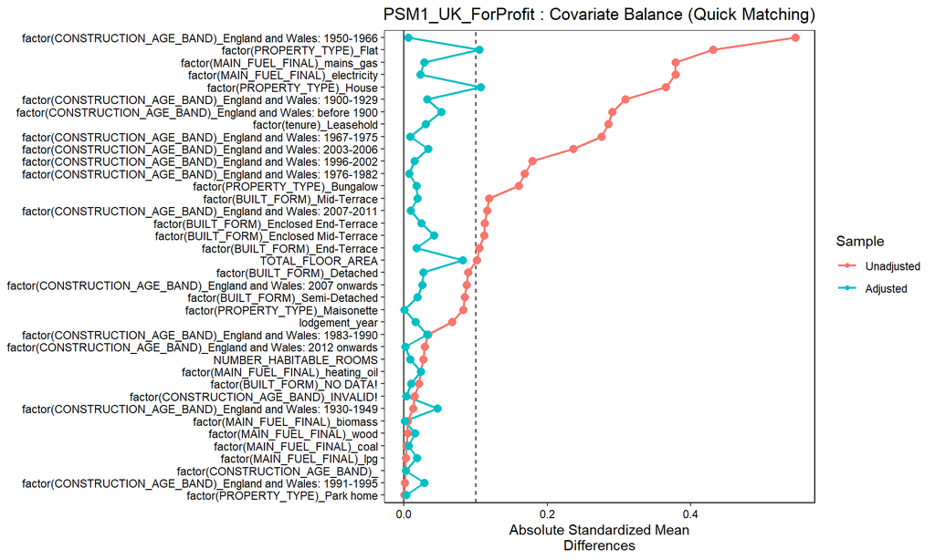

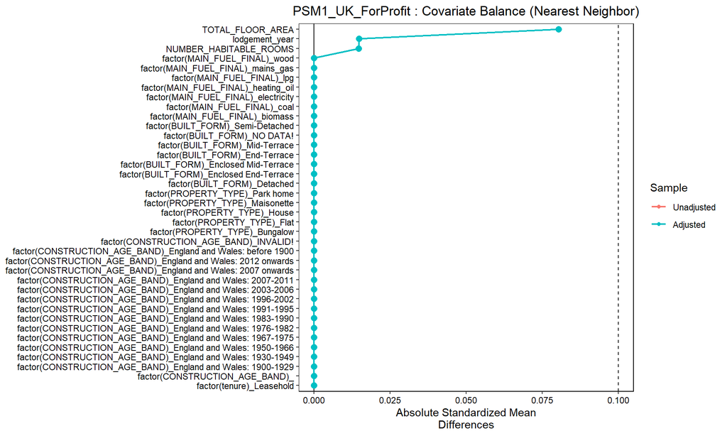

## Regression Analysis for PSM1_UK_ForProfit

```r
cat("\n## Regression Analysis for", analysis_id_1, "\n")
```

```
##
## ## Regression Analysis for PSM1_UK_ForProfit
```

```r
cat("Treatment:", treatment_var_1, "; Control: Otherwise (within matched sample - Nearest Neighbor)\n")
```

```
## Treatment: treat_uk_forprofit ; Control: Otherwise (within matched sample - Nearest Neighbor)
```

```r
mdata_reg_1 <- matching_results_1$mdata_nearest
if (nrow(mdata_reg_1) > 0) {
  reg_formula_simple_str <- paste(outcome_variable, "~", treatment_var_1)
  m_simple_1 <- feols(as.formula(reg_formula_simple_str), data = mdata_reg_1)
  cat("\n### Regression without fixed effects:\n")
  print(summary(m_simple_1))

  if ("subclass" %in% names(mdata_reg_1)) {
    mdata_reg_1[, LOCAL_AUTHORITY_SUBCLASS := paste(LOCAL_AUTHORITY_LABEL, subclass, sep = "_")]
    reg_formula_fe_str <- paste(outcome_variable, "~", treatment_var_1, "| LOCAL_AUTHORITY_SUBCLASS")
    m_fe_1 <- feols(as.formula(reg_formula_fe_str), data = mdata_reg_1)
    cat("\n### Regression with LOCAL_AUTHORITY_SUBCLASS fixed effects:\n")
    print(summary(m_fe_1))
  } else {
    cat("\n'subclass' column not found. Using LOCAL_AUTHORITY_LABEL as fixed effect instead:\n")
    reg_formula_la_fe_str <- paste(outcome_variable, "~", treatment_var_1, "| LOCAL_AUTHORITY_LABEL")
    m_la_fe_1 <- feols(as.formula(reg_formula_la_fe_str), data = mdata_reg_1)
    print(summary(m_la_fe_1))
  }
} else {
  cat("No matched data available for regression analysis for", analysis_id_1, "\n")
}
```

```
##
## ### Regression without fixed effects:
## OLS estimation, Dep. Var.: bad_EPC
## Observations: 278,876
## Standard-errors: IID
##                    Estimate Std. Error  t value  Pr(>|t|)
## (Intercept)        0.392339   0.001321 297.0571 < 2.2e-16 ***
## treat_uk_forprofit 0.063569   0.001868  34.0339 < 2.2e-16 ***
## ---
## Signif. codes:  0 '***' 0.001 '**' 0.01 '*' 0.05 '.' 0.1 ' ' 1
## RMSE: 0.493186   Adj. R2: 0.004133
##
## ### Regression with LOCAL_AUTHORITY_SUBCLASS fixed effects:
## OLS estimation, Dep. Var.: bad_EPC
## Observations: 278,876
## Fixed-effects: LOCAL_AUTHORITY_SUBCLASS: 139,438
## Standard-errors: Clustered (LOCAL_AUTHORITY_SUBCLASS)
##                    Estimate Std. Error t value  Pr(>|t|)
## treat_uk_forprofit 0.063569   0.001521  41.795 < 2.2e-16 ***
## ---
## Signif. codes:  0 '***' 0.001 '**' 0.01 '*' 0.05 '.' 0.1 ' ' 1
## RMSE: 0.283976     Adj. R2: 0.339651
##                  Within R2: 0.012373
```

# PSM Analysis 2: Non-UK For-Profits (`treat_foreign_forprofit`)

Treatment: Non-UK for-profit; Control: Otherwise

— Performing Matching for: PSM2_Foreign_ForProfit — Matching complete for PSM2_Foreign_ForProfit. Nearest matched N=31674, Quick matched N=317903

## Balance Assessment Tables for PSM2_Foreign_ForProfit

### Balance Table: Unadjusted

PSM2_Foreign_ForProfit : Balance - Unadjusted

|  | Type | M.0.Un | M.1.Un | Diff.Un | M.0.Adj | M.1.Adj | Diff.Adj |
| --- | --- | --- | --- | --- | --- | --- | --- |
| TOTAL_FLOOR_AREA | Contin. | 84.174 | 90.710 | 0.077 | NA | NA | NA |
| NUMBER_HABITABLE_ROOMS | Contin. | 3.995 | 3.375 | -0.323 | NA | NA | NA |
| lodgement_year | Contin. | 2016.918 | 2017.678 | 0.158 | NA | NA | NA |
| factor(tenure)_Freehold | Binary | 0.367 | 0.605 | 0.492 | NA | NA | NA |
| factor(tenure)_Leasehold | Binary | 0.050 | 0.395 | 0.912 | NA | NA | NA |
| factor(tenure)_Not in OCOD, CCOD | Binary | 0.584 | 0.000 | -1.675 | NA | NA | NA |
| factor(CONSTRUCTION_AGE_BAND)_ | Binary | 0.003 | 0.006 | 0.041 | NA | NA | NA |
| factor(CONSTRUCTION_AGE_BAND)_England and Wales: 1900-1929 | Binary | 0.192 | 0.133 | -0.159 | NA | NA | NA |
| factor(CONSTRUCTION_AGE_BAND)_England and Wales: 1930-1949 | Binary | 0.127 | 0.083 | -0.144 | NA | NA | NA |
| factor(CONSTRUCTION_AGE_BAND)_England and Wales: 1950-1966 | Binary | 0.163 | 0.041 | -0.412 | NA | NA | NA |
| factor(CONSTRUCTION_AGE_BAND)_England and Wales: 1967-1975 | Binary | 0.113 | 0.041 | -0.274 | NA | NA | NA |
| factor(CONSTRUCTION_AGE_BAND)_England and Wales: 1976-1982 | Binary | 0.053 | 0.023 | -0.156 | NA | NA | NA |
| factor(CONSTRUCTION_AGE_BAND)_England and Wales: 1983-1990 | Binary | 0.058 | 0.027 | -0.153 | NA | NA | NA |
| factor(CONSTRUCTION_AGE_BAND)_England and Wales: 1991-1995 | Binary | 0.035 | 0.029 | -0.037 | NA | NA | NA |
| factor(CONSTRUCTION_AGE_BAND)_England and Wales: 1996-2002 | Binary | 0.048 | 0.090 | 0.166 | NA | NA | NA |
| factor(CONSTRUCTION_AGE_BAND)_England and Wales: 2003-2006 | Binary | 0.041 | 0.177 | 0.445 | NA | NA | NA |
| factor(CONSTRUCTION_AGE_BAND)_England and Wales: 2007-2011 | Binary | 0.016 | 0.080 | 0.304 | NA | NA | NA |
| factor(CONSTRUCTION_AGE_BAND)_England and Wales: 2007 onwards | Binary | 0.017 | 0.096 | 0.345 | NA | NA | NA |
| factor(CONSTRUCTION_AGE_BAND)_England and Wales: 2012 onwards | Binary | 0.007 | 0.050 | 0.264 | NA | NA | NA |
| factor(CONSTRUCTION_AGE_BAND)_England and Wales: before 1900 | Binary | 0.124 | 0.119 | -0.016 | NA | NA | NA |
| factor(CONSTRUCTION_AGE_BAND)_INVALID! | Binary | 0.002 | 0.005 | 0.052 | NA | NA | NA |
| factor(PROPERTY_TYPE)_Bungalow | Binary | 0.076 | 0.004 | -0.375 | NA | NA | NA |
| factor(PROPERTY_TYPE)_Flat | Binary | 0.391 | 0.850 | 1.075 | NA | NA | NA |
| factor(PROPERTY_TYPE)_House | Binary | 0.496 | 0.102 | -0.951 | NA | NA | NA |
| factor(PROPERTY_TYPE)_Maisonette | Binary | 0.037 | 0.043 | 0.033 | NA | NA | NA |
| factor(PROPERTY_TYPE)_Park home | Binary | 0.000 | 0.000 | -0.028 | NA | NA | NA |
| factor(BUILT_FORM)_Detached | Binary | 0.179 | 0.083 | -0.288 | NA | NA | NA |
| factor(BUILT_FORM)_Enclosed End-Terrace | Binary | 0.021 | 0.061 | 0.201 | NA | NA | NA |
| factor(BUILT_FORM)_Enclosed Mid-Terrace | Binary | 0.019 | 0.067 | 0.238 | NA | NA | NA |
| factor(BUILT_FORM)_End-Terrace | Binary | 0.153 | 0.164 | 0.029 | NA | NA | NA |
| factor(BUILT_FORM)_Mid-Terrace | Binary | 0.369 | 0.484 | 0.234 | NA | NA | NA |
| factor(BUILT_FORM)_NO DATA! | Binary | 0.010 | 0.024 | 0.107 | NA | NA | NA |
| factor(BUILT_FORM)_Semi-Detached | Binary | 0.249 | 0.119 | -0.342 | NA | NA | NA |
| factor(MAIN_FUEL_FINAL)_biomass | Binary | 0.000 | 0.000 | 0.002 | NA | NA | NA |
| factor(MAIN_FUEL_FINAL)_coal | Binary | 0.001 | 0.000 | -0.034 | NA | NA | NA |
| factor(MAIN_FUEL_FINAL)_dual_fuel | Binary | 0.000 | 0.000 | -0.002 | NA | NA | NA |
| factor(MAIN_FUEL_FINAL)_electricity | Binary | 0.132 | 0.365 | 0.560 | NA | NA | NA |
| factor(MAIN_FUEL_FINAL)_heating_oil | Binary | 0.027 | 0.007 | -0.156 | NA | NA | NA |
| factor(MAIN_FUEL_FINAL)_lpg | Binary | 0.007 | 0.002 | -0.067 | NA | NA | NA |
| factor(MAIN_FUEL_FINAL)_mains_gas | Binary | 0.830 | 0.624 | -0.474 | NA | NA | NA |
| factor(MAIN_FUEL_FINAL)_wood | Binary | 0.003 | 0.001 | -0.046 | NA | NA | NA |

#### Observations (Unadjusted):

|  | Control | Treated |
| --- | --- | --- |
| All | 1560356 | 16445 |

### Balance Table: Nearest Neighbor Matching

PSM2_Foreign_ForProfit : Balance - Nearest Neighbor

|  | Type | M.0.Un | M.1.Un | Diff.Un | M.0.Adj | M.1.Adj | Diff.Adj |
| --- | --- | --- | --- | --- | --- | --- | --- |
| TOTAL_FLOOR_AREA | Contin. | 83.571 | 90.656 | 0.078 | 83.571 | 90.656 | 0.078 |
| NUMBER_HABITABLE_ROOMS | Contin. | 3.261 | 3.372 | 0.059 | 3.261 | 3.372 | 0.059 |
| lodgement_year | Contin. | 2017.407 | 2017.660 | 0.052 | 2017.407 | 2017.660 | 0.052 |
| factor(tenure)_Leasehold | Binary | 0.388 | 0.388 | 0.000 | 0.388 | 0.388 | 0.000 |
| factor(CONSTRUCTION_AGE_BAND)_ | Binary | 0.005 | 0.005 | 0.000 | 0.005 | 0.005 | 0.000 |
| factor(CONSTRUCTION_AGE_BAND)_England and Wales: 1900-1929 | Binary | 0.138 | 0.138 | 0.000 | 0.138 | 0.138 | 0.000 |
| factor(CONSTRUCTION_AGE_BAND)_England and Wales: 1930-1949 | Binary | 0.085 | 0.085 | 0.000 | 0.085 | 0.085 | 0.000 |
| factor(CONSTRUCTION_AGE_BAND)_England and Wales: 1950-1966 | Binary | 0.042 | 0.042 | 0.000 | 0.042 | 0.042 | 0.000 |
| factor(CONSTRUCTION_AGE_BAND)_England and Wales: 1967-1975 | Binary | 0.042 | 0.042 | 0.000 | 0.042 | 0.042 | 0.000 |
| factor(CONSTRUCTION_AGE_BAND)_England and Wales: 1976-1982 | Binary | 0.024 | 0.024 | 0.000 | 0.024 | 0.024 | 0.000 |
| factor(CONSTRUCTION_AGE_BAND)_England and Wales: 1983-1990 | Binary | 0.028 | 0.028 | 0.000 | 0.028 | 0.028 | 0.000 |
| factor(CONSTRUCTION_AGE_BAND)_England and Wales: 1991-1995 | Binary | 0.029 | 0.029 | 0.000 | 0.029 | 0.029 | 0.000 |
| factor(CONSTRUCTION_AGE_BAND)_England and Wales: 1996-2002 | Binary | 0.091 | 0.091 | 0.000 | 0.091 | 0.091 | 0.000 |
| factor(CONSTRUCTION_AGE_BAND)_England and Wales: 2003-2006 | Binary | 0.179 | 0.179 | 0.000 | 0.179 | 0.179 | 0.000 |
| factor(CONSTRUCTION_AGE_BAND)_England and Wales: 2007-2011 | Binary | 0.076 | 0.076 | 0.000 | 0.076 | 0.076 | 0.000 |
| factor(CONSTRUCTION_AGE_BAND)_England and Wales: 2007 onwards | Binary | 0.094 | 0.094 | 0.000 | 0.094 | 0.094 | 0.000 |
| factor(CONSTRUCTION_AGE_BAND)_England and Wales: 2012 onwards | Binary | 0.040 | 0.040 | 0.000 | 0.040 | 0.040 | 0.000 |
| factor(CONSTRUCTION_AGE_BAND)_England and Wales: before 1900 | Binary | 0.122 | 0.122 | 0.000 | 0.122 | 0.122 | 0.000 |
| factor(CONSTRUCTION_AGE_BAND)_INVALID! | Binary | 0.004 | 0.004 | 0.000 | 0.004 | 0.004 | 0.000 |
| factor(PROPERTY_TYPE)_Bungalow | Binary | 0.002 | 0.002 | 0.000 | 0.002 | 0.002 | 0.000 |
| factor(PROPERTY_TYPE)_Flat | Binary | 0.857 | 0.857 | 0.000 | 0.857 | 0.857 | 0.000 |
| factor(PROPERTY_TYPE)_House | Binary | 0.100 | 0.100 | 0.000 | 0.100 | 0.100 | 0.000 |
| factor(PROPERTY_TYPE)_Maisonette | Binary | 0.040 | 0.040 | 0.000 | 0.040 | 0.040 | 0.000 |
| factor(BUILT_FORM)_Detached | Binary | 0.081 | 0.081 | 0.000 | 0.081 | 0.081 | 0.000 |
| factor(BUILT_FORM)_Enclosed End-Terrace | Binary | 0.056 | 0.056 | 0.000 | 0.056 | 0.056 | 0.000 |
| factor(BUILT_FORM)_Enclosed Mid-Terrace | Binary | 0.066 | 0.066 | 0.000 | 0.066 | 0.066 | 0.000 |
| factor(BUILT_FORM)_End-Terrace | Binary | 0.162 | 0.162 | 0.000 | 0.162 | 0.162 | 0.000 |
| factor(BUILT_FORM)_Mid-Terrace | Binary | 0.494 | 0.494 | 0.000 | 0.494 | 0.494 | 0.000 |
| factor(BUILT_FORM)_NO DATA! | Binary | 0.022 | 0.022 | 0.000 | 0.022 | 0.022 | 0.000 |
| factor(BUILT_FORM)_Semi-Detached | Binary | 0.119 | 0.119 | 0.000 | 0.119 | 0.119 | 0.000 |
| factor(MAIN_FUEL_FINAL)_biomass | Binary | 0.000 | 0.000 | 0.000 | 0.000 | 0.000 | 0.000 |
| factor(MAIN_FUEL_FINAL)_coal | Binary | 0.000 | 0.000 | 0.000 | 0.000 | 0.000 | 0.000 |
| factor(MAIN_FUEL_FINAL)_electricity | Binary | 0.366 | 0.366 | 0.000 | 0.366 | 0.366 | 0.000 |
| factor(MAIN_FUEL_FINAL)_heating_oil | Binary | 0.006 | 0.006 | 0.000 | 0.006 | 0.006 | 0.000 |
| factor(MAIN_FUEL_FINAL)_lpg | Binary | 0.001 | 0.001 | 0.000 | 0.001 | 0.001 | 0.000 |
| factor(MAIN_FUEL_FINAL)_mains_gas | Binary | 0.626 | 0.626 | 0.000 | 0.626 | 0.626 | 0.000 |
| factor(MAIN_FUEL_FINAL)_wood | Binary | 0.001 | 0.001 | 0.000 | 0.001 | 0.001 | 0.000 |

#### Observations (Nearest Neighbor):

|  | Control | Treated |
| --- | --- | --- |
| All (ESS) | 15837 | 15837 |
| All (Unweighted) | 15837 | 15837 |
| Matched (ESS) | 15837 | 15837 |
| Matched (Unweighted) | 15837 | 15837 |
| Unmatched | 0 | 0 |

### Balance Table: Quick Matching

PSM2_Foreign_ForProfit : Balance - Quick Matching

|  | Type | M.0.Un | M.1.Un | Diff.Un | M.0.Adj | M.1.Adj | Diff.Adj |
| --- | --- | --- | --- | --- | --- | --- | --- |
| TOTAL_FLOOR_AREA | Contin. | 69.493 | 90.468 | 0.271 | 76.863 | 90.468 | 0.176 |
| NUMBER_HABITABLE_ROOMS | Contin. | 3.160 | 3.374 | 0.124 | 3.128 | 3.374 | 0.142 |
| lodgement_year | Contin. | 2017.253 | 2017.671 | 0.087 | 2017.497 | 2017.671 | 0.036 |
| factor(tenure)_Leasehold | Binary | 0.138 | 0.394 | 0.605 | 0.332 | 0.394 | 0.145 |
| factor(CONSTRUCTION_AGE_BAND)_ | Binary | 0.001 | 0.006 | 0.083 | 0.004 | 0.006 | 0.034 |
| factor(CONSTRUCTION_AGE_BAND)_England and Wales: 1900-1929 | Binary | 0.195 | 0.135 | -0.163 | 0.129 | 0.135 | 0.015 |
| factor(CONSTRUCTION_AGE_BAND)_England and Wales: 1930-1949 | Binary | 0.121 | 0.084 | -0.122 | 0.068 | 0.084 | 0.053 |
| factor(CONSTRUCTION_AGE_BAND)_England and Wales: 1950-1966 | Binary | 0.140 | 0.042 | -0.348 | 0.041 | 0.042 | 0.001 |
| factor(CONSTRUCTION_AGE_BAND)_England and Wales: 1967-1975 | Binary | 0.085 | 0.041 | -0.181 | 0.036 | 0.041 | 0.022 |
| factor(CONSTRUCTION_AGE_BAND)_England and Wales: 1976-1982 | Binary | 0.036 | 0.023 | -0.075 | 0.023 | 0.023 | 0.001 |
| factor(CONSTRUCTION_AGE_BAND)_England and Wales: 1983-1990 | Binary | 0.052 | 0.027 | -0.127 | 0.037 | 0.027 | -0.047 |
| factor(CONSTRUCTION_AGE_BAND)_England and Wales: 1991-1995 | Binary | 0.035 | 0.029 | -0.035 | 0.044 | 0.029 | -0.089 |
| factor(CONSTRUCTION_AGE_BAND)_England and Wales: 1996-2002 | Binary | 0.069 | 0.091 | 0.083 | 0.090 | 0.091 | 0.002 |
| factor(CONSTRUCTION_AGE_BAND)_England and Wales: 2003-2006 | Binary | 0.087 | 0.178 | 0.270 | 0.182 | 0.178 | -0.011 |
| factor(CONSTRUCTION_AGE_BAND)_England and Wales: 2007-2011 | Binary | 0.038 | 0.079 | 0.174 | 0.089 | 0.079 | -0.041 |
| factor(CONSTRUCTION_AGE_BAND)_England and Wales: 2007 onwards | Binary | 0.033 | 0.095 | 0.256 | 0.119 | 0.095 | -0.095 |
| factor(CONSTRUCTION_AGE_BAND)_England and Wales: 2012 onwards | Binary | 0.011 | 0.046 | 0.216 | 0.050 | 0.046 | -0.024 |
| factor(CONSTRUCTION_AGE_BAND)_England and Wales: before 1900 | Binary | 0.097 | 0.120 | 0.074 | 0.084 | 0.120 | 0.114 |
| factor(CONSTRUCTION_AGE_BAND)_INVALID! | Binary | 0.001 | 0.004 | 0.065 | 0.004 | 0.004 | -0.002 |
| factor(PROPERTY_TYPE)_Bungalow | Binary | 0.002 | 0.003 | 0.004 | 0.004 | 0.003 | -0.036 |
| factor(PROPERTY_TYPE)_Flat | Binary | 0.777 | 0.856 | 0.205 | 0.849 | 0.856 | 0.018 |
| factor(PROPERTY_TYPE)_House | Binary | 0.189 | 0.101 | -0.252 | 0.104 | 0.101 | -0.009 |
| factor(PROPERTY_TYPE)_Maisonette | Binary | 0.031 | 0.040 | 0.048 | 0.042 | 0.040 | -0.011 |
| factor(BUILT_FORM)_Detached | Binary | 0.057 | 0.081 | 0.096 | 0.085 | 0.081 | -0.016 |
| factor(BUILT_FORM)_Enclosed End-Terrace | Binary | 0.034 | 0.058 | 0.115 | 0.060 | 0.058 | -0.009 |
| factor(BUILT_FORM)_Enclosed Mid-Terrace | Binary | 0.036 | 0.066 | 0.136 | 0.059 | 0.066 | 0.030 |
| factor(BUILT_FORM)_End-Terrace | Binary | 0.178 | 0.164 | -0.036 | 0.166 | 0.164 | -0.005 |
| factor(BUILT_FORM)_Mid-Terrace | Binary | 0.531 | 0.489 | -0.084 | 0.467 | 0.489 | 0.044 |
| factor(BUILT_FORM)_NO DATA! | Binary | 0.011 | 0.023 | 0.097 | 0.023 | 0.023 | 0.000 |
| factor(BUILT_FORM)_Semi-Detached | Binary | 0.154 | 0.119 | -0.102 | 0.139 | 0.119 | -0.060 |
| factor(MAIN_FUEL_FINAL)_biomass | Binary | 0.000 | 0.000 | 0.014 | 0.000 | 0.000 | -0.001 |
| factor(MAIN_FUEL_FINAL)_coal | Binary | 0.000 | 0.000 | 0.012 | 0.000 | 0.000 | 0.005 |
| factor(MAIN_FUEL_FINAL)_electricity | Binary | 0.201 | 0.364 | 0.369 | 0.377 | 0.364 | -0.029 |
| factor(MAIN_FUEL_FINAL)_heating_oil | Binary | 0.002 | 0.006 | 0.066 | 0.003 | 0.006 | 0.048 |
| factor(MAIN_FUEL_FINAL)_lpg | Binary | 0.000 | 0.002 | 0.049 | 0.000 | 0.002 | 0.039 |
| factor(MAIN_FUEL_FINAL)_mains_gas | Binary | 0.797 | 0.627 | -0.382 | 0.619 | 0.627 | 0.018 |
| factor(MAIN_FUEL_FINAL)_wood | Binary | 0.000 | 0.000 | 0.026 | 0.000 | 0.000 | 0.021 |

#### Observations (Quick Matching):

|  | Control | Treated |
| --- | --- | --- |
| All (ESS) | 301724.00 | 16179 |
| All (Unweighted) | 301724.00 | 16179 |
| Matched (ESS) | 18541.19 | 16179 |
| Matched (Unweighted) | 301724.00 | 16179 |
| Unmatched | 0.00 | 0 |

## Love Plots for PSM2_Foreign_ForProfit

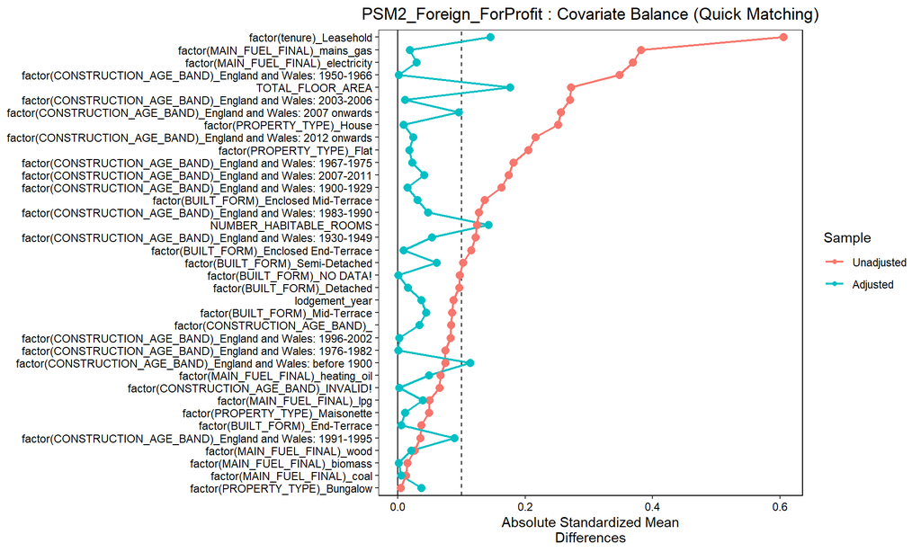

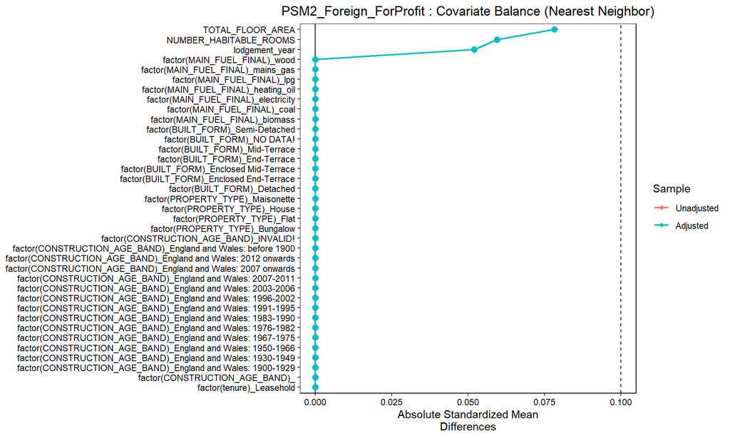

## Regression Analysis for PSM2_Foreign_ForProfit

```r
cat("\n## Regression Analysis for", analysis_id_2, "\n")
```

```
##
## ## Regression Analysis for PSM2_Foreign_ForProfit
```

```r
cat("Treatment:", treatment_var_2, "; Control: Otherwise (within matched sample - Nearest Neighbor)\n")
```

```
## Treatment: treat_foreign_forprofit ; Control: Otherwise (within matched sample - Nearest Neighbor)
```

```r
mdata_reg_2 <- matching_results_2$mdata_nearest
if (nrow(mdata_reg_2) > 0) {
  # ... (regression code similar to PSM1)
  reg_formula_simple_str <- paste(outcome_variable, "~", treatment_var_2)
  m_simple_2 <- feols(as.formula(reg_formula_simple_str), data = mdata_reg_2)
  print(summary(m_simple_2))
  if ("subclass" %in% names(mdata_reg_2)) {
    mdata_reg_2[, LOCAL_AUTHORITY_SUBCLASS := paste(LOCAL_AUTHORITY_LABEL, subclass, sep = "_")]
    reg_formula_fe_str <- paste(outcome_variable, "~", treatment_var_2, "| LOCAL_AUTHORITY_SUBCLASS")
    m_fe_2 <- feols(as.formula(reg_formula_fe_str), data = mdata_reg_2)
    print(summary(m_fe_2))
  } else {
    reg_formula_la_fe_str <- paste(outcome_variable, "~", treatment_var_2, "| LOCAL_AUTHORITY_LABEL")
    m_la_fe_2 <- feols(as.formula(reg_formula_la_fe_str), data = mdata_reg_2)
    print(summary(m_la_fe_2))
  }
} else { cat("No matched data for regression in", analysis_id_2, "\n") }
```

```
## OLS estimation, Dep. Var.: bad_EPC
## Observations: 31,674
## Standard-errors: IID
##                          Estimate Std. Error  t value  Pr(>|t|)
## (Intercept)              0.323736   0.003702 87.45615 < 2.2e-16 ***
## treat_foreign_forprofit -0.010671   0.005235 -2.03844  0.041514 *
## ---
## Signif. codes:  0 '***' 0.001 '**' 0.01 '*' 0.05 '.' 0.1 ' ' 1
## RMSE: 0.465825   Adj. R2: 9.961e-5
## OLS estimation, Dep. Var.: bad_EPC
## Observations: 31,674
## Fixed-effects: LOCAL_AUTHORITY_SUBCLASS: 15,837
## Standard-errors: Clustered (LOCAL_AUTHORITY_SUBCLASS)
##                          Estimate Std. Error  t value  Pr(>|t|)
## treat_foreign_forprofit -0.010671   0.004089 -2.60972 0.0090702 **
## ---
## Signif. codes:  0 '***' 0.001 '**' 0.01 '*' 0.05 '.' 0.1 ' ' 1
## RMSE: 0.25728     Adj. R2: 0.389967
##                 Within R2: 4.299e-4
```

# PSM Analysis 3a: UK for profit (`treat_uk_forprofit`) (within For-Profits)

Treatment: UK for-profit; Control: all other for-profits (i.e., non-UK for-profits)

— Performing Matching for: PSM3a_UK_vs_Foreign_FP_within_ForProfits — Subset applied for PSM3a_UK_vs_Foreign_FP_within_ForProfits. Rows after subset: 419867 Matching complete for PSM3a_UK_vs_Foreign_FP_within_ForProfits. Nearest matched N=30692, Quick matched N=184367

## Balance Assessment Tables for PSM3a_UK_vs_Foreign_FP_within_ForProfits

### Balance Table: Unadjusted

PSM3a_UK_vs_Foreign_FP_within_ForProfits : Balance - Unadjusted

|  | Type | M.0.Un | M.1.Un | Diff.Un | M.0.Adj | M.1.Adj | Diff.Adj |
| --- | --- | --- | --- | --- | --- | --- | --- |
| TOTAL_FLOOR_AREA | Contin. | 90.710 | 70.750 | -0.211 | NA | NA | NA |
| NUMBER_HABITABLE_ROOMS | Contin. | 3.375 | 3.190 | -0.106 | NA | NA | NA |
| lodgement_year | Contin. | 2017.678 | 2017.304 | -0.078 | NA | NA | NA |
| factor(tenure)_Leasehold | Binary | 0.395 | 0.186 | -0.473 | NA | NA | NA |
| factor(CONSTRUCTION_AGE_BAND)_ | Binary | 0.006 | 0.003 | -0.040 | NA | NA | NA |
| factor(CONSTRUCTION_AGE_BAND)_England and Wales: 1900-1929 | Binary | 0.133 | 0.186 | 0.145 | NA | NA | NA |
| factor(CONSTRUCTION_AGE_BAND)_England and Wales: 1930-1949 | Binary | 0.083 | 0.101 | 0.061 | NA | NA | NA |
| factor(CONSTRUCTION_AGE_BAND)_England and Wales: 1950-1966 | Binary | 0.041 | 0.085 | 0.180 | NA | NA | NA |
| factor(CONSTRUCTION_AGE_BAND)_England and Wales: 1967-1975 | Binary | 0.041 | 0.077 | 0.155 | NA | NA | NA |
| factor(CONSTRUCTION_AGE_BAND)_England and Wales: 1976-1982 | Binary | 0.023 | 0.040 | 0.096 | NA | NA | NA |
| factor(CONSTRUCTION_AGE_BAND)_England and Wales: 1983-1990 | Binary | 0.027 | 0.076 | 0.221 | NA | NA | NA |
| factor(CONSTRUCTION_AGE_BAND)_England and Wales: 1991-1995 | Binary | 0.029 | 0.045 | 0.087 | NA | NA | NA |
| factor(CONSTRUCTION_AGE_BAND)_England and Wales: 1996-2002 | Binary | 0.090 | 0.082 | -0.029 | NA | NA | NA |
| factor(CONSTRUCTION_AGE_BAND)_England and Wales: 2003-2006 | Binary | 0.177 | 0.097 | -0.234 | NA | NA | NA |
| factor(CONSTRUCTION_AGE_BAND)_England and Wales: 2007-2011 | Binary | 0.080 | 0.040 | -0.168 | NA | NA | NA |
| factor(CONSTRUCTION_AGE_BAND)_England and Wales: 2007 onwards | Binary | 0.096 | 0.037 | -0.236 | NA | NA | NA |
| factor(CONSTRUCTION_AGE_BAND)_England and Wales: 2012 onwards | Binary | 0.050 | 0.014 | -0.207 | NA | NA | NA |
| factor(CONSTRUCTION_AGE_BAND)_England and Wales: before 1900 | Binary | 0.119 | 0.114 | -0.014 | NA | NA | NA |
| factor(CONSTRUCTION_AGE_BAND)_INVALID! | Binary | 0.005 | 0.003 | -0.040 | NA | NA | NA |
| factor(PROPERTY_TYPE)_Bungalow | Binary | 0.004 | 0.018 | 0.138 | NA | NA | NA |
| factor(PROPERTY_TYPE)_Flat | Binary | 0.850 | 0.765 | -0.219 | NA | NA | NA |
| factor(PROPERTY_TYPE)_House | Binary | 0.102 | 0.163 | 0.180 | NA | NA | NA |
| factor(PROPERTY_TYPE)_Maisonette | Binary | 0.043 | 0.053 | 0.044 | NA | NA | NA |
| factor(PROPERTY_TYPE)_Park home | Binary | 0.000 | 0.001 | 0.041 | NA | NA | NA |
| factor(BUILT_FORM)_Detached | Binary | 0.083 | 0.084 | 0.006 | NA | NA | NA |
| factor(BUILT_FORM)_Enclosed End-Terrace | Binary | 0.061 | 0.051 | -0.043 | NA | NA | NA |
| factor(BUILT_FORM)_Enclosed Mid-Terrace | Binary | 0.067 | 0.046 | -0.089 | NA | NA | NA |
| factor(BUILT_FORM)_End-Terrace | Binary | 0.164 | 0.172 | 0.023 | NA | NA | NA |
| factor(BUILT_FORM)_Mid-Terrace | Binary | 0.484 | 0.430 | -0.108 | NA | NA | NA |
| factor(BUILT_FORM)_NO DATA! | Binary | 0.024 | 0.018 | -0.035 | NA | NA | NA |
| factor(BUILT_FORM)_Semi-Detached | Binary | 0.119 | 0.198 | 0.218 | NA | NA | NA |
| factor(MAIN_FUEL_FINAL)_biomass | Binary | 0.000 | 0.001 | 0.007 | NA | NA | NA |
| factor(MAIN_FUEL_FINAL)_coal | Binary | 0.000 | 0.001 | 0.010 | NA | NA | NA |
| factor(MAIN_FUEL_FINAL)_dual_fuel | Binary | 0.000 | 0.000 | 0.003 | NA | NA | NA |
| factor(MAIN_FUEL_FINAL)_electricity | Binary | 0.365 | 0.305 | -0.127 | NA | NA | NA |
| factor(MAIN_FUEL_FINAL)_heating_oil | Binary | 0.007 | 0.008 | 0.017 | NA | NA | NA |
| factor(MAIN_FUEL_FINAL)_lpg | Binary | 0.002 | 0.003 | 0.014 | NA | NA | NA |
| factor(MAIN_FUEL_FINAL)_mains_gas | Binary | 0.624 | 0.681 | 0.120 | NA | NA | NA |
| factor(MAIN_FUEL_FINAL)_wood | Binary | 0.001 | 0.001 | 0.004 | NA | NA | NA |

#### Observations (Unadjusted):

|  | Control | Treated |
| --- | --- | --- |
| All | 16445 | 290740 |

### Balance Table: Nearest Neighbor Matching

PSM3a_UK_vs_Foreign_FP_within_ForProfits : Balance - Nearest Neighbor

|  | Type | M.0.Un | M.1.Un | Diff.Un | M.0.Adj | M.1.Adj | Diff.Adj |
| --- | --- | --- | --- | --- | --- | --- | --- |
| TOTAL_FLOOR_AREA | Contin. | 90.306 | 60.246 | -0.391 | 90.306 | 60.246 | -0.391 |
| NUMBER_HABITABLE_ROOMS | Contin. | 3.367 | 2.949 | -0.223 | 3.367 | 2.949 | -0.223 |
| lodgement_year | Contin. | 2017.642 | 2016.101 | -0.305 | 2017.642 | 2016.101 | -0.305 |
| factor(tenure)_Leasehold | Binary | 0.381 | 0.381 | 0.000 | 0.381 | 0.381 | 0.000 |
| factor(CONSTRUCTION_AGE_BAND)_ | Binary | 0.003 | 0.003 | 0.000 | 0.003 | 0.003 | 0.000 |
| factor(CONSTRUCTION_AGE_BAND)_England and Wales: 1900-1929 | Binary | 0.141 | 0.141 | 0.000 | 0.141 | 0.141 | 0.000 |
| factor(CONSTRUCTION_AGE_BAND)_England and Wales: 1930-1949 | Binary | 0.087 | 0.087 | 0.000 | 0.087 | 0.087 | 0.000 |
| factor(CONSTRUCTION_AGE_BAND)_England and Wales: 1950-1966 | Binary | 0.044 | 0.044 | 0.000 | 0.044 | 0.044 | 0.000 |
| factor(CONSTRUCTION_AGE_BAND)_England and Wales: 1967-1975 | Binary | 0.043 | 0.043 | 0.000 | 0.043 | 0.043 | 0.000 |
| factor(CONSTRUCTION_AGE_BAND)_England and Wales: 1976-1982 | Binary | 0.024 | 0.024 | 0.000 | 0.024 | 0.024 | 0.000 |
| factor(CONSTRUCTION_AGE_BAND)_England and Wales: 1983-1990 | Binary | 0.028 | 0.028 | 0.000 | 0.028 | 0.028 | 0.000 |
| factor(CONSTRUCTION_AGE_BAND)_England and Wales: 1991-1995 | Binary | 0.029 | 0.029 | 0.000 | 0.029 | 0.029 | 0.000 |
| factor(CONSTRUCTION_AGE_BAND)_England and Wales: 1996-2002 | Binary | 0.092 | 0.092 | 0.000 | 0.092 | 0.092 | 0.000 |
| factor(CONSTRUCTION_AGE_BAND)_England and Wales: 2003-2006 | Binary | 0.183 | 0.183 | 0.000 | 0.183 | 0.183 | 0.000 |
| factor(CONSTRUCTION_AGE_BAND)_England and Wales: 2007-2011 | Binary | 0.073 | 0.073 | 0.000 | 0.073 | 0.073 | 0.000 |
| factor(CONSTRUCTION_AGE_BAND)_England and Wales: 2007 onwards | Binary | 0.089 | 0.089 | 0.000 | 0.089 | 0.089 | 0.000 |
| factor(CONSTRUCTION_AGE_BAND)_England and Wales: 2012 onwards | Binary | 0.035 | 0.035 | 0.000 | 0.035 | 0.035 | 0.000 |
| factor(CONSTRUCTION_AGE_BAND)_England and Wales: before 1900 | Binary | 0.126 | 0.126 | 0.000 | 0.126 | 0.126 | 0.000 |
| factor(CONSTRUCTION_AGE_BAND)_INVALID! | Binary | 0.003 | 0.003 | 0.000 | 0.003 | 0.003 | 0.000 |
| factor(PROPERTY_TYPE)_Bungalow | Binary | 0.002 | 0.002 | 0.000 | 0.002 | 0.002 | 0.000 |
| factor(PROPERTY_TYPE)_Flat | Binary | 0.858 | 0.858 | 0.000 | 0.858 | 0.858 | 0.000 |
| factor(PROPERTY_TYPE)_House | Binary | 0.100 | 0.100 | 0.000 | 0.100 | 0.100 | 0.000 |
| factor(PROPERTY_TYPE)_Maisonette | Binary | 0.040 | 0.040 | 0.000 | 0.040 | 0.040 | 0.000 |
| factor(BUILT_FORM)_Detached | Binary | 0.079 | 0.079 | 0.000 | 0.079 | 0.079 | 0.000 |
| factor(BUILT_FORM)_Enclosed End-Terrace | Binary | 0.055 | 0.055 | 0.000 | 0.055 | 0.055 | 0.000 |
| factor(BUILT_FORM)_Enclosed Mid-Terrace | Binary | 0.066 | 0.066 | 0.000 | 0.066 | 0.066 | 0.000 |
| factor(BUILT_FORM)_End-Terrace | Binary | 0.161 | 0.161 | 0.000 | 0.161 | 0.161 | 0.000 |
| factor(BUILT_FORM)_Mid-Terrace | Binary | 0.499 | 0.499 | 0.000 | 0.499 | 0.499 | 0.000 |
| factor(BUILT_FORM)_NO DATA! | Binary | 0.021 | 0.021 | 0.000 | 0.021 | 0.021 | 0.000 |
| factor(BUILT_FORM)_Semi-Detached | Binary | 0.120 | 0.120 | 0.000 | 0.120 | 0.120 | 0.000 |
| factor(MAIN_FUEL_FINAL)_biomass | Binary | 0.000 | 0.000 | 0.000 | 0.000 | 0.000 | 0.000 |
| factor(MAIN_FUEL_FINAL)_coal | Binary | 0.000 | 0.000 | 0.000 | 0.000 | 0.000 | 0.000 |
| factor(MAIN_FUEL_FINAL)_electricity | Binary | 0.367 | 0.367 | 0.000 | 0.367 | 0.367 | 0.000 |
| factor(MAIN_FUEL_FINAL)_heating_oil | Binary | 0.006 | 0.006 | 0.000 | 0.006 | 0.006 | 0.000 |
| factor(MAIN_FUEL_FINAL)_lpg | Binary | 0.001 | 0.001 | 0.000 | 0.001 | 0.001 | 0.000 |
| factor(MAIN_FUEL_FINAL)_mains_gas | Binary | 0.625 | 0.625 | 0.000 | 0.625 | 0.625 | 0.000 |
| factor(MAIN_FUEL_FINAL)_wood | Binary | 0.000 | 0.000 | 0.000 | 0.000 | 0.000 | 0.000 |

#### Observations (Nearest Neighbor):

|  | Control | Treated |
| --- | --- | --- |
| All (ESS) | 15346 | 15346 |
| All (Unweighted) | 15346 | 15346 |
| Matched (ESS) | 15346 | 15346 |
| Matched (Unweighted) | 15346 | 15346 |
| Unmatched | 0 | 0 |

### Balance Table: Quick Matching

PSM3a_UK_vs_Foreign_FP_within_ForProfits : Balance - Quick Matching

|  | Type | M.0.Un | M.1.Un | Diff.Un | M.0.Adj | M.1.Adj | Diff.Adj |
| --- | --- | --- | --- | --- | --- | --- | --- |
| TOTAL_FLOOR_AREA | Contin. | 90.430 | 72.079 | -0.235 | 75.973 | 72.079 | -0.050 |
| NUMBER_HABITABLE_ROOMS | Contin. | 3.368 | 3.155 | -0.123 | 3.155 | 3.155 | 0.000 |
| lodgement_year | Contin. | 2017.681 | 2017.388 | -0.061 | 2017.371 | 2017.388 | 0.004 |
| factor(tenure)_Leasehold | Binary | 0.394 | 0.187 | -0.468 | 0.207 | 0.187 | -0.045 |
| factor(CONSTRUCTION_AGE_BAND)_ | Binary | 0.004 | 0.001 | -0.064 | 0.002 | 0.001 | -0.011 |
| factor(CONSTRUCTION_AGE_BAND)_England and Wales: 1900-1929 | Binary | 0.136 | 0.241 | 0.273 | 0.224 | 0.241 | 0.044 |
| factor(CONSTRUCTION_AGE_BAND)_England and Wales: 1930-1949 | Binary | 0.084 | 0.117 | 0.108 | 0.125 | 0.117 | -0.029 |
| factor(CONSTRUCTION_AGE_BAND)_England and Wales: 1950-1966 | Binary | 0.042 | 0.057 | 0.071 | 0.056 | 0.057 | 0.004 |
| factor(CONSTRUCTION_AGE_BAND)_England and Wales: 1967-1975 | Binary | 0.041 | 0.042 | 0.006 | 0.043 | 0.042 | -0.005 |
| factor(CONSTRUCTION_AGE_BAND)_England and Wales: 1976-1982 | Binary | 0.023 | 0.022 | -0.006 | 0.022 | 0.022 | 0.002 |
| factor(CONSTRUCTION_AGE_BAND)_England and Wales: 1983-1990 | Binary | 0.027 | 0.053 | 0.130 | 0.042 | 0.053 | 0.054 |
| factor(CONSTRUCTION_AGE_BAND)_England and Wales: 1991-1995 | Binary | 0.029 | 0.036 | 0.039 | 0.031 | 0.036 | 0.027 |
| factor(CONSTRUCTION_AGE_BAND)_England and Wales: 1996-2002 | Binary | 0.091 | 0.088 | -0.008 | 0.092 | 0.088 | -0.012 |
| factor(CONSTRUCTION_AGE_BAND)_England and Wales: 2003-2006 | Binary | 0.179 | 0.117 | -0.175 | 0.113 | 0.117 | 0.011 |
| factor(CONSTRUCTION_AGE_BAND)_England and Wales: 2007-2011 | Binary | 0.079 | 0.050 | -0.122 | 0.042 | 0.050 | 0.029 |
| factor(CONSTRUCTION_AGE_BAND)_England and Wales: 2007 onwards | Binary | 0.095 | 0.039 | -0.225 | 0.040 | 0.039 | -0.005 |
| factor(CONSTRUCTION_AGE_BAND)_England and Wales: 2012 onwards | Binary | 0.046 | 0.012 | -0.203 | 0.011 | 0.012 | 0.005 |
| factor(CONSTRUCTION_AGE_BAND)_England and Wales: before 1900 | Binary | 0.121 | 0.124 | 0.010 | 0.155 | 0.124 | -0.093 |
| factor(CONSTRUCTION_AGE_BAND)_INVALID! | Binary | 0.003 | 0.001 | -0.051 | 0.001 | 0.001 | -0.002 |
| factor(PROPERTY_TYPE)_Bungalow | Binary | 0.002 | 0.001 | -0.026 | 0.001 | 0.001 | 0.004 |
| factor(PROPERTY_TYPE)_Flat | Binary | 0.859 | 0.851 | -0.022 | 0.872 | 0.851 | -0.060 |
| factor(PROPERTY_TYPE)_House | Binary | 0.100 | 0.113 | 0.044 | 0.093 | 0.113 | 0.067 |
| factor(PROPERTY_TYPE)_Maisonette | Binary | 0.039 | 0.035 | -0.025 | 0.034 | 0.035 | 0.001 |
| factor(BUILT_FORM)_Detached | Binary | 0.081 | 0.057 | -0.096 | 0.062 | 0.057 | -0.020 |
| factor(BUILT_FORM)_Enclosed End-Terrace | Binary | 0.058 | 0.041 | -0.079 | 0.041 | 0.041 | -0.001 |
| factor(BUILT_FORM)_Enclosed Mid-Terrace | Binary | 0.066 | 0.044 | -0.096 | 0.054 | 0.044 | -0.045 |
| factor(BUILT_FORM)_End-Terrace | Binary | 0.162 | 0.159 | -0.009 | 0.160 | 0.159 | -0.002 |
| factor(BUILT_FORM)_Mid-Terrace | Binary | 0.491 | 0.541 | 0.100 | 0.541 | 0.541 | -0.001 |
| factor(BUILT_FORM)_NO DATA! | Binary | 0.023 | 0.013 | -0.079 | 0.015 | 0.013 | -0.020 |
| factor(BUILT_FORM)_Semi-Detached | Binary | 0.119 | 0.146 | 0.081 | 0.126 | 0.146 | 0.058 |
| factor(MAIN_FUEL_FINAL)_biomass | Binary | 0.000 | 0.000 | -0.010 | 0.000 | 0.000 | -0.001 |
| factor(MAIN_FUEL_FINAL)_coal | Binary | 0.000 | 0.000 | -0.010 | 0.000 | 0.000 | -0.001 |
| factor(MAIN_FUEL_FINAL)_electricity | Binary | 0.365 | 0.275 | -0.194 | 0.264 | 0.275 | 0.024 |
| factor(MAIN_FUEL_FINAL)_heating_oil | Binary | 0.006 | 0.003 | -0.058 | 0.005 | 0.003 | -0.035 |
| factor(MAIN_FUEL_FINAL)_lpg | Binary | 0.002 | 0.000 | -0.044 | 0.001 | 0.000 | -0.022 |
| factor(MAIN_FUEL_FINAL)_mains_gas | Binary | 0.626 | 0.722 | 0.205 | 0.730 | 0.722 | -0.017 |
| factor(MAIN_FUEL_FINAL)_wood | Binary | 0.000 | 0.000 | -0.020 | 0.000 | 0.000 | -0.018 |

#### Observations (Quick Matching):

|  | Control | Treated |
| --- | --- | --- |
| All (ESS) | 16056.000 | 168311 |
| All (Unweighted) | 16056.000 | 168311 |
| Matched (ESS) | 3303.631 | 168311 |
| Matched (Unweighted) | 16056.000 | 168311 |
| Unmatched | 0.000 | 0 |

## Love Plots for PSM3a_UK_vs_Foreign_FP_within_ForProfits

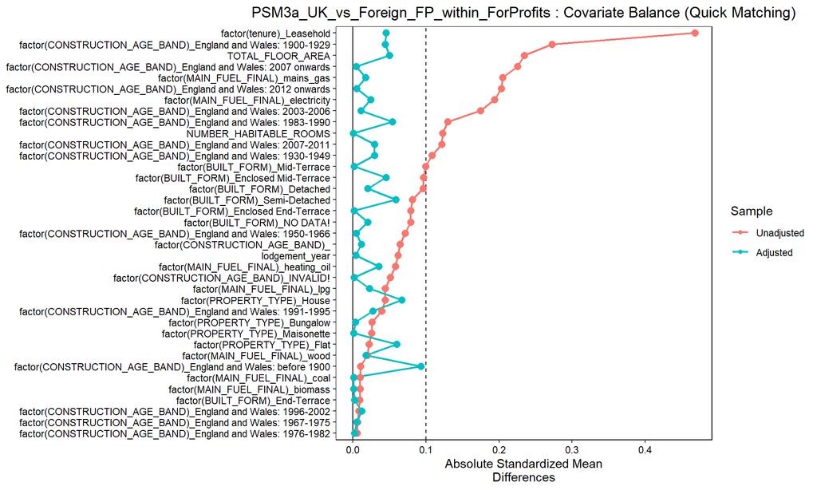

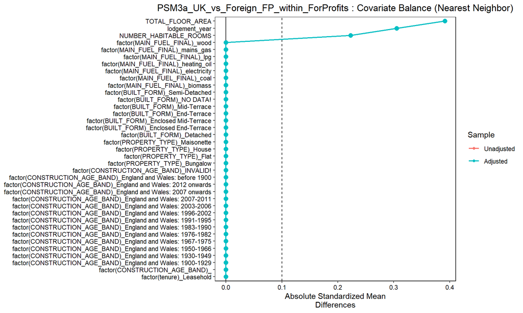

## Regression Analysis for PSM3a_UK_vs_Foreign_FP_within_ForProfits

```r
cat("\n## Regression Analysis for", analysis_id_3a, "\n")
```

```
##
## ## Regression Analysis for PSM3a_UK_vs_Foreign_FP_within_ForProfits
```

```r
cat("Treatment:", treatment_var_3a, "; Control: Foreign For-Profit (within matched sample - Nearest Neighbor)\n")
```

```
## Treatment: treat_uk_forprofit ; Control: Foreign For-Profit (within matched sample - Nearest Neighbor)
```

```r
mdata_reg_3a <- matching_results_3a$mdata_nearest
if (nrow(mdata_reg_3a) > 0) {
  # ... (regression code similar to PSM1)
  reg_formula_simple_str <- paste(outcome_variable, "~", treatment_var_3a)
  m_simple_3a <- feols(as.formula(reg_formula_simple_str), data = mdata_reg_3a)
  print(summary(m_simple_3a))
  if ("subclass" %in% names(mdata_reg_3a)) {
    mdata_reg_3a[, LOCAL_AUTHORITY_SUBCLASS := paste(LOCAL_AUTHORITY_LABEL, subclass, sep = "_")]
    reg_formula_fe_str <- paste(outcome_variable, "~", treatment_var_3a, "| LOCAL_AUTHORITY_SUBCLASS")
    m_fe_3a <- feols(as.formula(reg_formula_fe_str), data = mdata_reg_3a)
    print(summary(m_fe_3a))
  } else {
    reg_formula_la_fe_str <- paste(outcome_variable, "~", treatment_var_3a, "| LOCAL_AUTHORITY_LABEL")
    m_la_fe_3a <- feols(as.formula(reg_formula_la_fe_str), data = mdata_reg_3a)
    print(summary(m_la_fe_3a))
  }
} else { cat("No matched data for regression in", analysis_id_3a, "\n") }
```

```
## OLS estimation, Dep. Var.: bad_EPC
## Observations: 30,692
## Standard-errors: IID
##                    Estimate Std. Error  t value   Pr(>|t|)
## (Intercept)        0.318650   0.003799 83.88233  < 2.2e-16 ***
## treat_uk_forprofit 0.025674   0.005372  4.77906 1.7693e-06 ***
## ---
## Signif. codes:  0 '***' 0.001 '**' 0.01 '*' 0.05 '.' 0.1 ' ' 1
## RMSE: 0.470573   Adj. R2: 7.111e-4
## OLS estimation, Dep. Var.: bad_EPC
## Observations: 30,692
## Fixed-effects: LOCAL_AUTHORITY_SUBCLASS: 15,346
## Standard-errors: Clustered (LOCAL_AUTHORITY_SUBCLASS)
##                    Estimate Std. Error t value   Pr(>|t|)
## treat_uk_forprofit 0.025674    0.00425 6.04063 1.5706e-09 ***
## ---
## Signif. codes:  0 '***' 0.001 '**' 0.01 '*' 0.05 '.' 0.1 ' ' 1
## RMSE: 0.263248     Adj. R2: 0.374542
##                  Within R2: 0.002372
```

# PSM Analysis 3b: Tax Haven (`treat_tax_haven`) (within For-Profits)

Treatment: tax haven for-profit; Control: all other (non-tax haven) for-profits

— Performing Matching for: PSM3b_TaxHaven_vs_NonTaxHaven_FP_within_ForProfits — Subset applied for PSM3b_TaxHaven_vs_NonTaxHaven_FP_within_ForProfits. Rows after subset: 419867 Matching complete for PSM3b_TaxHaven_vs_NonTaxHaven_FP_within_ForProfits. Nearest matched N=29722, Quick matched N=181628

## Balance Assessment Tables for PSM3b_TaxHaven_vs_NonTaxHaven_FP_within_ForProfits

### Balance Table: Unadjusted

PSM3b_TaxHaven_vs_NonTaxHaven_FP_within_ForProfits : Balance - Unadjusted

|  | Type | M.0.Un | M.1.Un | Diff.Un | M.0.Adj | M.1.Adj | Diff.Adj |
| --- | --- | --- | --- | --- | --- | --- | --- |
| TOTAL_FLOOR_AREA | Contin. | 70.784 | 90.744 | 0.210 | NA | NA | NA |
| NUMBER_HABITABLE_ROOMS | Contin. | 3.191 | 3.368 | 0.101 | NA | NA | NA |
| lodgement_year | Contin. | 2017.302 | 2017.739 | 0.091 | NA | NA | NA |
| factor(tenure)_Leasehold | Binary | 0.186 | 0.396 | 0.474 | NA | NA | NA |
| factor(CONSTRUCTION_AGE_BAND)_ | Binary | 0.003 | 0.006 | 0.042 | NA | NA | NA |
| factor(CONSTRUCTION_AGE_BAND)_England and Wales: 1900-1929 | Binary | 0.186 | 0.128 | -0.160 | NA | NA | NA |
| factor(CONSTRUCTION_AGE_BAND)_England and Wales: 1930-1949 | Binary | 0.101 | 0.082 | -0.065 | NA | NA | NA |
| factor(CONSTRUCTION_AGE_BAND)_England and Wales: 1950-1966 | Binary | 0.085 | 0.040 | -0.186 | NA | NA | NA |
| factor(CONSTRUCTION_AGE_BAND)_England and Wales: 1967-1975 | Binary | 0.077 | 0.041 | -0.154 | NA | NA | NA |
| factor(CONSTRUCTION_AGE_BAND)_England and Wales: 1976-1982 | Binary | 0.040 | 0.023 | -0.098 | NA | NA | NA |
| factor(CONSTRUCTION_AGE_BAND)_England and Wales: 1983-1990 | Binary | 0.076 | 0.027 | -0.221 | NA | NA | NA |
| factor(CONSTRUCTION_AGE_BAND)_England and Wales: 1991-1995 | Binary | 0.045 | 0.029 | -0.086 | NA | NA | NA |
| factor(CONSTRUCTION_AGE_BAND)_England and Wales: 1996-2002 | Binary | 0.082 | 0.092 | 0.034 | NA | NA | NA |
| factor(CONSTRUCTION_AGE_BAND)_England and Wales: 2003-2006 | Binary | 0.097 | 0.181 | 0.246 | NA | NA | NA |
| factor(CONSTRUCTION_AGE_BAND)_England and Wales: 2007-2011 | Binary | 0.040 | 0.082 | 0.175 | NA | NA | NA |
| factor(CONSTRUCTION_AGE_BAND)_England and Wales: 2007 onwards | Binary | 0.038 | 0.093 | 0.225 | NA | NA | NA |
| factor(CONSTRUCTION_AGE_BAND)_England and Wales: 2012 onwards | Binary | 0.014 | 0.052 | 0.214 | NA | NA | NA |
| factor(CONSTRUCTION_AGE_BAND)_England and Wales: before 1900 | Binary | 0.114 | 0.120 | 0.017 | NA | NA | NA |
| factor(CONSTRUCTION_AGE_BAND)_INVALID! | Binary | 0.003 | 0.005 | 0.042 | NA | NA | NA |
| factor(PROPERTY_TYPE)_Bungalow | Binary | 0.018 | 0.004 | -0.139 | NA | NA | NA |
| factor(PROPERTY_TYPE)_Flat | Binary | 0.765 | 0.857 | 0.239 | NA | NA | NA |
| factor(PROPERTY_TYPE)_House | Binary | 0.164 | 0.096 | -0.203 | NA | NA | NA |
| factor(PROPERTY_TYPE)_Maisonette | Binary | 0.053 | 0.043 | -0.046 | NA | NA | NA |
| factor(PROPERTY_TYPE)_Park home | Binary | 0.001 | 0.000 | -0.041 | NA | NA | NA |
| factor(BUILT_FORM)_Detached | Binary | 0.084 | 0.082 | -0.008 | NA | NA | NA |
| factor(BUILT_FORM)_Enclosed End-Terrace | Binary | 0.051 | 0.062 | 0.048 | NA | NA | NA |
| factor(BUILT_FORM)_Enclosed Mid-Terrace | Binary | 0.046 | 0.068 | 0.095 | NA | NA | NA |
| factor(BUILT_FORM)_End-Terrace | Binary | 0.172 | 0.165 | -0.020 | NA | NA | NA |
| factor(BUILT_FORM)_Mid-Terrace | Binary | 0.430 | 0.481 | 0.101 | NA | NA | NA |
| factor(BUILT_FORM)_NO DATA! | Binary | 0.018 | 0.024 | 0.038 | NA | NA | NA |
| factor(BUILT_FORM)_Semi-Detached | Binary | 0.198 | 0.118 | -0.218 | NA | NA | NA |
| factor(MAIN_FUEL_FINAL)_biomass | Binary | 0.001 | 0.000 | -0.006 | NA | NA | NA |
| factor(MAIN_FUEL_FINAL)_coal | Binary | 0.001 | 0.000 | -0.010 | NA | NA | NA |
| factor(MAIN_FUEL_FINAL)_dual_fuel | Binary | 0.000 | 0.000 | -0.003 | NA | NA | NA |
| factor(MAIN_FUEL_FINAL)_electricity | Binary | 0.306 | 0.367 | 0.130 | NA | NA | NA |
| factor(MAIN_FUEL_FINAL)_heating_oil | Binary | 0.008 | 0.006 | -0.021 | NA | NA | NA |
| factor(MAIN_FUEL_FINAL)_lpg | Binary | 0.003 | 0.002 | -0.015 | NA | NA | NA |
| factor(MAIN_FUEL_FINAL)_mains_gas | Binary | 0.681 | 0.623 | -0.122 | NA | NA | NA |
| factor(MAIN_FUEL_FINAL)_wood | Binary | 0.001 | 0.001 | -0.003 | NA | NA | NA |

#### Observations (Unadjusted):

|  | Control | Treated |
| --- | --- | --- |
| All | 291263 | 15922 |

### Balance Table: Nearest Neighbor Matching

PSM3b_TaxHaven_vs_NonTaxHaven_FP_within_ForProfits : Balance - Nearest Neighbor

|  | Type | M.0.Un | M.1.Un | Diff.Un | M.0.Adj | M.1.Adj | Diff.Adj |
| --- | --- | --- | --- | --- | --- | --- | --- |
| TOTAL_FLOOR_AREA | Contin. | 83.212 | 91.376 | 0.093 | 83.212 | 91.376 | 0.093 |
| NUMBER_HABITABLE_ROOMS | Contin. | 3.230 | 3.374 | 0.078 | 3.230 | 3.374 | 0.078 |
| lodgement_year | Contin. | 2017.718 | 2017.714 | -0.001 | 2017.718 | 2017.714 | -0.001 |
| factor(tenure)_Leasehold | Binary | 0.381 | 0.381 | 0.000 | 0.381 | 0.381 | 0.000 |
| factor(CONSTRUCTION_AGE_BAND)_ | Binary | 0.003 | 0.003 | 0.000 | 0.003 | 0.003 | 0.000 |
| factor(CONSTRUCTION_AGE_BAND)_England and Wales: 1900-1929 | Binary | 0.137 | 0.137 | 0.000 | 0.137 | 0.137 | 0.000 |
| factor(CONSTRUCTION_AGE_BAND)_England and Wales: 1930-1949 | Binary | 0.086 | 0.086 | 0.000 | 0.086 | 0.086 | 0.000 |
| factor(CONSTRUCTION_AGE_BAND)_England and Wales: 1950-1966 | Binary | 0.042 | 0.042 | 0.000 | 0.042 | 0.042 | 0.000 |
| factor(CONSTRUCTION_AGE_BAND)_England and Wales: 1967-1975 | Binary | 0.043 | 0.043 | 0.000 | 0.043 | 0.043 | 0.000 |
| factor(CONSTRUCTION_AGE_BAND)_England and Wales: 1976-1982 | Binary | 0.023 | 0.023 | 0.000 | 0.023 | 0.023 | 0.000 |
| factor(CONSTRUCTION_AGE_BAND)_England and Wales: 1983-1990 | Binary | 0.028 | 0.028 | 0.000 | 0.028 | 0.028 | 0.000 |
| factor(CONSTRUCTION_AGE_BAND)_England and Wales: 1991-1995 | Binary | 0.030 | 0.030 | 0.000 | 0.030 | 0.030 | 0.000 |
| factor(CONSTRUCTION_AGE_BAND)_England and Wales: 1996-2002 | Binary | 0.094 | 0.094 | 0.000 | 0.094 | 0.094 | 0.000 |
| factor(CONSTRUCTION_AGE_BAND)_England and Wales: 2003-2006 | Binary | 0.188 | 0.188 | 0.000 | 0.188 | 0.188 | 0.000 |
| factor(CONSTRUCTION_AGE_BAND)_England and Wales: 2007-2011 | Binary | 0.075 | 0.075 | 0.000 | 0.075 | 0.075 | 0.000 |
| factor(CONSTRUCTION_AGE_BAND)_England and Wales: 2007 onwards | Binary | 0.085 | 0.085 | 0.000 | 0.085 | 0.085 | 0.000 |
| factor(CONSTRUCTION_AGE_BAND)_England and Wales: 2012 onwards | Binary | 0.036 | 0.036 | 0.000 | 0.036 | 0.036 | 0.000 |
| factor(CONSTRUCTION_AGE_BAND)_England and Wales: before 1900 | Binary | 0.127 | 0.127 | 0.000 | 0.127 | 0.127 | 0.000 |
| factor(CONSTRUCTION_AGE_BAND)_INVALID! | Binary | 0.003 | 0.003 | 0.000 | 0.003 | 0.003 | 0.000 |
| factor(PROPERTY_TYPE)_Bungalow | Binary | 0.002 | 0.002 | 0.000 | 0.002 | 0.002 | 0.000 |
| factor(PROPERTY_TYPE)_Flat | Binary | 0.865 | 0.865 | 0.000 | 0.865 | 0.865 | 0.000 |
| factor(PROPERTY_TYPE)_House | Binary | 0.093 | 0.093 | 0.000 | 0.093 | 0.093 | 0.000 |
| factor(PROPERTY_TYPE)_Maisonette | Binary | 0.040 | 0.040 | 0.000 | 0.040 | 0.040 | 0.000 |
| factor(BUILT_FORM)_Detached | Binary | 0.078 | 0.078 | 0.000 | 0.078 | 0.078 | 0.000 |
| factor(BUILT_FORM)_Enclosed End-Terrace | Binary | 0.056 | 0.056 | 0.000 | 0.056 | 0.056 | 0.000 |
| factor(BUILT_FORM)_Enclosed Mid-Terrace | Binary | 0.068 | 0.068 | 0.000 | 0.068 | 0.068 | 0.000 |
| factor(BUILT_FORM)_End-Terrace | Binary | 0.162 | 0.162 | 0.000 | 0.162 | 0.162 | 0.000 |
| factor(BUILT_FORM)_Mid-Terrace | Binary | 0.495 | 0.495 | 0.000 | 0.495 | 0.495 | 0.000 |
| factor(BUILT_FORM)_NO DATA! | Binary | 0.021 | 0.021 | 0.000 | 0.021 | 0.021 | 0.000 |
| factor(BUILT_FORM)_Semi-Detached | Binary | 0.120 | 0.120 | 0.000 | 0.120 | 0.120 | 0.000 |
| factor(MAIN_FUEL_FINAL)_biomass | Binary | 0.000 | 0.000 | 0.000 | 0.000 | 0.000 | 0.000 |
| factor(MAIN_FUEL_FINAL)_coal | Binary | 0.000 | 0.000 | 0.000 | 0.000 | 0.000 | 0.000 |
| factor(MAIN_FUEL_FINAL)_electricity | Binary | 0.369 | 0.369 | 0.000 | 0.369 | 0.369 | 0.000 |
| factor(MAIN_FUEL_FINAL)_heating_oil | Binary | 0.006 | 0.006 | 0.000 | 0.006 | 0.006 | 0.000 |
| factor(MAIN_FUEL_FINAL)_lpg | Binary | 0.001 | 0.001 | 0.000 | 0.001 | 0.001 | 0.000 |
| factor(MAIN_FUEL_FINAL)_mains_gas | Binary | 0.623 | 0.623 | 0.000 | 0.623 | 0.623 | 0.000 |
| factor(MAIN_FUEL_FINAL)_wood | Binary | 0.000 | 0.000 | 0.000 | 0.000 | 0.000 | 0.000 |

#### Observations (Nearest Neighbor):

|  | Control | Treated |
| --- | --- | --- |
| All (ESS) | 14861 | 14861 |
| All (Unweighted) | 14861 | 14861 |
| Matched (ESS) | 14861 | 14861 |
| Matched (Unweighted) | 14861 | 14861 |
| Unmatched | 0 | 0 |

### Balance Table: Quick Matching

PSM3b_TaxHaven_vs_NonTaxHaven_FP_within_ForProfits : Balance - Quick Matching

|  | Type | M.0.Un | M.1.Un | Diff.Un | M.0.Adj | M.1.Adj | Diff.Adj |
| --- | --- | --- | --- | --- | --- | --- | --- |
| TOTAL_FLOOR_AREA | Contin. | 72.062 | 90.466 | 0.233 | 79.287 | 90.466 | 0.142 |
| NUMBER_HABITABLE_ROOMS | Contin. | 3.149 | 3.361 | 0.122 | 3.149 | 3.361 | 0.122 |
| lodgement_year | Contin. | 2017.387 | 2017.743 | 0.074 | 2017.716 | 2017.743 | 0.006 |
| factor(tenure)_Leasehold | Binary | 0.190 | 0.395 | 0.464 | 0.350 | 0.395 | 0.102 |
| factor(CONSTRUCTION_AGE_BAND)_ | Binary | 0.001 | 0.004 | 0.066 | 0.003 | 0.004 | 0.023 |
| factor(CONSTRUCTION_AGE_BAND)_England and Wales: 1900-1929 | Binary | 0.240 | 0.131 | -0.285 | 0.126 | 0.131 | 0.013 |
| factor(CONSTRUCTION_AGE_BAND)_England and Wales: 1930-1949 | Binary | 0.117 | 0.083 | -0.112 | 0.069 | 0.083 | 0.048 |
| factor(CONSTRUCTION_AGE_BAND)_England and Wales: 1950-1966 | Binary | 0.056 | 0.041 | -0.073 | 0.038 | 0.041 | 0.011 |
| factor(CONSTRUCTION_AGE_BAND)_England and Wales: 1967-1975 | Binary | 0.040 | 0.041 | 0.009 | 0.040 | 0.041 | 0.009 |
| factor(CONSTRUCTION_AGE_BAND)_England and Wales: 1976-1982 | Binary | 0.021 | 0.023 | 0.010 | 0.024 | 0.023 | -0.012 |
| factor(CONSTRUCTION_AGE_BAND)_England and Wales: 1983-1990 | Binary | 0.053 | 0.027 | -0.133 | 0.037 | 0.027 | -0.052 |
| factor(CONSTRUCTION_AGE_BAND)_England and Wales: 1991-1995 | Binary | 0.036 | 0.029 | -0.041 | 0.044 | 0.029 | -0.087 |
| factor(CONSTRUCTION_AGE_BAND)_England and Wales: 1996-2002 | Binary | 0.090 | 0.092 | 0.008 | 0.089 | 0.092 | 0.012 |
| factor(CONSTRUCTION_AGE_BAND)_England and Wales: 2003-2006 | Binary | 0.118 | 0.183 | 0.182 | 0.186 | 0.183 | -0.008 |
| factor(CONSTRUCTION_AGE_BAND)_England and Wales: 2007-2011 | Binary | 0.050 | 0.081 | 0.126 | 0.090 | 0.081 | -0.036 |
| factor(CONSTRUCTION_AGE_BAND)_England and Wales: 2007 onwards | Binary | 0.040 | 0.092 | 0.213 | 0.107 | 0.092 | -0.061 |
| factor(CONSTRUCTION_AGE_BAND)_England and Wales: 2012 onwards | Binary | 0.012 | 0.048 | 0.209 | 0.051 | 0.048 | -0.021 |
| factor(CONSTRUCTION_AGE_BAND)_England and Wales: before 1900 | Binary | 0.125 | 0.122 | -0.010 | 0.092 | 0.122 | 0.091 |
| factor(CONSTRUCTION_AGE_BAND)_INVALID! | Binary | 0.001 | 0.003 | 0.052 | 0.004 | 0.003 | -0.007 |
| factor(PROPERTY_TYPE)_Bungalow | Binary | 0.001 | 0.002 | 0.024 | 0.003 | 0.002 | -0.024 |
| factor(PROPERTY_TYPE)_Flat | Binary | 0.856 | 0.866 | 0.029 | 0.865 | 0.866 | 0.002 |
| factor(PROPERTY_TYPE)_House | Binary | 0.108 | 0.093 | -0.051 | 0.090 | 0.093 | 0.012 |
| factor(PROPERTY_TYPE)_Maisonette | Binary | 0.035 | 0.039 | 0.022 | 0.042 | 0.039 | -0.017 |
| factor(BUILT_FORM)_Detached | Binary | 0.056 | 0.080 | 0.096 | 0.083 | 0.080 | -0.009 |
| factor(BUILT_FORM)_Enclosed End-Terrace | Binary | 0.041 | 0.059 | 0.081 | 0.063 | 0.059 | -0.019 |
| factor(BUILT_FORM)_Enclosed Mid-Terrace | Binary | 0.044 | 0.067 | 0.099 | 0.062 | 0.067 | 0.020 |
| factor(BUILT_FORM)_End-Terrace | Binary | 0.158 | 0.163 | 0.014 | 0.163 | 0.163 | 0.001 |
| factor(BUILT_FORM)_Mid-Terrace | Binary | 0.544 | 0.488 | -0.112 | 0.465 | 0.488 | 0.045 |
| factor(BUILT_FORM)_NO DATA! | Binary | 0.013 | 0.023 | 0.080 | 0.023 | 0.023 | 0.004 |
| factor(BUILT_FORM)_Semi-Detached | Binary | 0.143 | 0.119 | -0.074 | 0.140 | 0.119 | -0.064 |
| factor(MAIN_FUEL_FINAL)_biomass | Binary | 0.000 | 0.000 | 0.010 | 0.000 | 0.000 | 0.004 |
| factor(MAIN_FUEL_FINAL)_coal | Binary | 0.000 | 0.000 | 0.010 | 0.000 | 0.000 | 0.004 |
| factor(MAIN_FUEL_FINAL)_electricity | Binary | 0.278 | 0.367 | 0.190 | 0.392 | 0.367 | -0.055 |
| factor(MAIN_FUEL_FINAL)_heating_oil | Binary | 0.003 | 0.006 | 0.054 | 0.003 | 0.006 | 0.043 |
| factor(MAIN_FUEL_FINAL)_lpg | Binary | 0.000 | 0.002 | 0.045 | 0.000 | 0.002 | 0.036 |
| factor(MAIN_FUEL_FINAL)_mains_gas | Binary | 0.719 | 0.625 | -0.201 | 0.604 | 0.625 | 0.045 |
| factor(MAIN_FUEL_FINAL)_wood | Binary | 0.000 | 0.000 | 0.020 | 0.000 | 0.000 | 0.020 |

#### Observations (Quick Matching):

|  | Control | Treated |
| --- | --- | --- |
| All (ESS) | 166082.00 | 15546 |
| All (Unweighted) | 166082.00 | 15546 |
| Matched (ESS) | 14662.19 | 15546 |
| Matched (Unweighted) | 166082.00 | 15546 |
| Unmatched | 0.00 | 0 |

## Love Plots for PSM3b_TaxHaven_vs_NonTaxHaven_FP_within_ForProfits

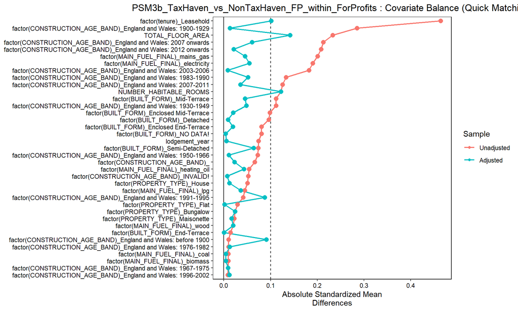

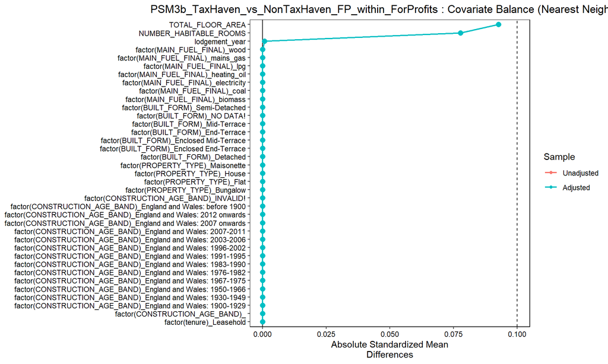

## Regression Analysis for PSM3b_TaxHaven_vs_NonTaxHaven_FP_within_ForProfits

```r
cat("\n## Regression Analysis for", analysis_id_3b, "\n")
```

```
##
## ## Regression Analysis for PSM3b_TaxHaven_vs_NonTaxHaven_FP_within_ForProfits
```

```r
cat("Treatment:", treatment_var_3b, "; Control: Non-Tax Haven For-Profit (within matched sample - Nearest Neighbor)\n")
```

```
## Treatment: treat_tax_haven ; Control: Non-Tax Haven For-Profit (within matched sample - Nearest Neighbor)
```

```r
mdata_reg_3b <- matching_results_3b$mdata_nearest
if (nrow(mdata_reg_3b) > 0) {
  # ... (regression code similar to PSM1)
  reg_formula_simple_str <- paste(outcome_variable, "~", treatment_var_3b)
  m_simple_3b <- feols(as.formula(reg_formula_simple_str), data = mdata_reg_3b)
  print(summary(m_simple_3b))
  if ("subclass" %in% names(mdata_reg_3b)) {
    mdata_reg_3b[, LOCAL_AUTHORITY_SUBCLASS := paste(LOCAL_AUTHORITY_LABEL, subclass, sep = "_")]
    reg_formula_fe_str <- paste(outcome_variable, "~", treatment_var_3b, "| LOCAL_AUTHORITY_SUBCLASS")
    m_fe_3b <- feols(as.formula(reg_formula_fe_str), data = mdata_reg_3b)
    print(summary(m_fe_3b))
  } else {
    reg_formula_la_fe_str <- paste(outcome_variable, "~", treatment_var_3b, "| LOCAL_AUTHORITY_LABEL")
    m_la_fe_3b <- feols(as.formula(reg_formula_la_fe_str), data = mdata_reg_3b)
    print(summary(m_la_fe_3b))
  }
} else { cat("No matched data for regression in", analysis_id_3b, "\n") }
```

```
## OLS estimation, Dep. Var.: bad_EPC
## Observations: 29,722
## Standard-errors: IID
##                  Estimate Std. Error  t value  Pr(>|t|)
## (Intercept)      0.327636   0.003827 85.61103 < 2.2e-16 ***
## treat_tax_haven -0.014737   0.005412 -2.72282 0.0064765 **
## ---
## Signif. codes:  0 '***' 0.001 '**' 0.01 '*' 0.05 '.' 0.1 ' ' 1
## RMSE: 0.466521   Adj. R2: 2.158e-4
## OLS estimation, Dep. Var.: bad_EPC
## Observations: 29,722
## Fixed-effects: LOCAL_AUTHORITY_SUBCLASS: 14,861
## Standard-errors: Clustered (LOCAL_AUTHORITY_SUBCLASS)
##                  Estimate Std. Error  t value   Pr(>|t|)
## treat_tax_haven -0.014737   0.004259 -3.46002 0.00054164 ***
## ---
## Signif. codes:  0 '***' 0.001 '**' 0.01 '*' 0.05 '.' 0.1 ' ' 1
## RMSE: 0.259591     Adj. R2: 0.380884
##                  Within R2: 8.05e-4
```

# PSM Analysis 4: UK Public Sector (`treat_uk_public`)

Treatment: UK public sector (mostly councils); Control: otherwise

— Performing Matching for: PSM4_UK_Public_Sector — Matching complete for PSM4_UK_Public_Sector. Nearest matched N=132356, Quick matched N=431112

## Balance Assessment Tables for PSM4_UK_Public_Sector

### Balance Table: Unadjusted

PSM4_UK_Public_Sector : Balance - Unadjusted

|  | Type | M.0.Un | M.1.Un | Diff.Un | M.0.Adj | M.1.Adj | Diff.Adj |
| --- | --- | --- | --- | --- | --- | --- | --- |
| TOTAL_FLOOR_AREA | Contin. | 86.478 | 63.234 | -0.492 | NA | NA | NA |
| NUMBER_HABITABLE_ROOMS | Contin. | 4.082 | 3.108 | -0.643 | NA | NA | NA |
| lodgement_year | Contin. | 2016.910 | 2017.075 | 0.035 | NA | NA | NA |
| factor(tenure)_Freehold | Binary | 0.304 | 0.981 | 1.993 | NA | NA | NA |
| factor(tenure)_Leasehold | Binary | 0.057 | 0.019 | -0.197 | NA | NA | NA |
| factor(tenure)_Not in OCOD, CCOD | Binary | 0.639 | 0.000 | -1.882 | NA | NA | NA |
| factor(CONSTRUCTION_AGE_BAND)_ | Binary | 0.003 | 0.004 | 0.011 | NA | NA | NA |
| factor(CONSTRUCTION_AGE_BAND)_England and Wales: 1900-1929 | Binary | 0.205 | 0.062 | -0.429 | NA | NA | NA |
| factor(CONSTRUCTION_AGE_BAND)_England and Wales: 1930-1949 | Binary | 0.129 | 0.104 | -0.078 | NA | NA | NA |
| factor(CONSTRUCTION_AGE_BAND)_England and Wales: 1950-1966 | Binary | 0.135 | 0.416 | 0.661 | NA | NA | NA |
| factor(CONSTRUCTION_AGE_BAND)_England and Wales: 1967-1975 | Binary | 0.099 | 0.234 | 0.366 | NA | NA | NA |
| factor(CONSTRUCTION_AGE_BAND)_England and Wales: 1976-1982 | Binary | 0.049 | 0.085 | 0.144 | NA | NA | NA |
| factor(CONSTRUCTION_AGE_BAND)_England and Wales: 1983-1990 | Binary | 0.060 | 0.033 | -0.127 | NA | NA | NA |
| factor(CONSTRUCTION_AGE_BAND)_England and Wales: 1991-1995 | Binary | 0.038 | 0.011 | -0.170 | NA | NA | NA |
| factor(CONSTRUCTION_AGE_BAND)_England and Wales: 1996-2002 | Binary | 0.053 | 0.008 | -0.262 | NA | NA | NA |
| factor(CONSTRUCTION_AGE_BAND)_England and Wales: 2003-2006 | Binary | 0.047 | 0.008 | -0.241 | NA | NA | NA |
| factor(CONSTRUCTION_AGE_BAND)_England and Wales: 2007-2011 | Binary | 0.018 | 0.005 | -0.122 | NA | NA | NA |
| factor(CONSTRUCTION_AGE_BAND)_England and Wales: 2007 onwards | Binary | 0.020 | 0.003 | -0.157 | NA | NA | NA |
| factor(CONSTRUCTION_AGE_BAND)_England and Wales: 2012 onwards | Binary | 0.007 | 0.003 | -0.066 | NA | NA | NA |
| factor(CONSTRUCTION_AGE_BAND)_England and Wales: before 1900 | Binary | 0.134 | 0.024 | -0.419 | NA | NA | NA |
| factor(CONSTRUCTION_AGE_BAND)_INVALID! | Binary | 0.002 | 0.001 | -0.047 | NA | NA | NA |
| factor(PROPERTY_TYPE)_Bungalow | Binary | 0.079 | 0.041 | -0.161 | NA | NA | NA |
| factor(PROPERTY_TYPE)_Flat | Binary | 0.371 | 0.626 | 0.528 | NA | NA | NA |
| factor(PROPERTY_TYPE)_House | Binary | 0.520 | 0.223 | -0.645 | NA | NA | NA |
| factor(PROPERTY_TYPE)_Maisonette | Binary | 0.029 | 0.109 | 0.319 | NA | NA | NA |
| factor(PROPERTY_TYPE)_Park home | Binary | 0.000 | 0.000 | -0.027 | NA | NA | NA |
| factor(BUILT_FORM)_Detached | Binary | 0.187 | 0.090 | -0.283 | NA | NA | NA |
| factor(BUILT_FORM)_Enclosed End-Terrace | Binary | 0.021 | 0.025 | 0.027 | NA | NA | NA |
| factor(BUILT_FORM)_Enclosed Mid-Terrace | Binary | 0.020 | 0.017 | -0.025 | NA | NA | NA |
| factor(BUILT_FORM)_End-Terrace | Binary | 0.144 | 0.241 | 0.248 | NA | NA | NA |
| factor(BUILT_FORM)_Mid-Terrace | Binary | 0.365 | 0.418 | 0.108 | NA | NA | NA |
| factor(BUILT_FORM)_NO DATA! | Binary | 0.010 | 0.014 | 0.039 | NA | NA | NA |
| factor(BUILT_FORM)_Semi-Detached | Binary | 0.253 | 0.196 | -0.138 | NA | NA | NA |
| factor(MAIN_FUEL_FINAL)_biomass | Binary | 0.000 | 0.000 | -0.011 | NA | NA | NA |
| factor(MAIN_FUEL_FINAL)_coal | Binary | 0.001 | 0.001 | -0.027 | NA | NA | NA |
| factor(MAIN_FUEL_FINAL)_dual_fuel | Binary | 0.000 | 0.000 | -0.002 | NA | NA | NA |
| factor(MAIN_FUEL_FINAL)_electricity | Binary | 0.137 | 0.115 | -0.066 | NA | NA | NA |
| factor(MAIN_FUEL_FINAL)_heating_oil | Binary | 0.029 | 0.003 | -0.211 | NA | NA | NA |
| factor(MAIN_FUEL_FINAL)_lpg | Binary | 0.008 | 0.003 | -0.060 | NA | NA | NA |
| factor(MAIN_FUEL_FINAL)_mains_gas | Binary | 0.822 | 0.878 | 0.158 | NA | NA | NA |
| factor(MAIN_FUEL_FINAL)_wood | Binary | 0.003 | 0.000 | -0.064 | NA | NA | NA |

#### Observations (Unadjusted):

|  | Control | Treated |
| --- | --- | --- |
| All | 1425184 | 151617 |

### Balance Table: Nearest Neighbor Matching

PSM4_UK_Public_Sector : Balance - Nearest Neighbor

|  | Type | M.0.Un | M.1.Un | Diff.Un | M.0.Adj | M.1.Adj | Diff.Adj |
| --- | --- | --- | --- | --- | --- | --- | --- |
| TOTAL_FLOOR_AREA | Contin. | 67.524 | 60.464 | -0.280 | 67.524 | 60.464 | -0.280 |
| NUMBER_HABITABLE_ROOMS | Contin. | 3.232 | 2.989 | -0.192 | 3.232 | 2.989 | -0.192 |
| lodgement_year | Contin. | 2017.102 | 2017.151 | 0.010 | 2017.102 | 2017.151 | 0.010 |
| factor(tenure)_Leasehold | Binary | 0.040 | 0.040 | 0.000 | 0.040 | 0.040 | 0.000 |
| factor(CONSTRUCTION_AGE_BAND)_ | Binary | 0.004 | 0.004 | 0.000 | 0.004 | 0.004 | 0.000 |
| factor(CONSTRUCTION_AGE_BAND)_England and Wales: 1900-1929 | Binary | 0.140 | 0.140 | 0.000 | 0.140 | 0.140 | 0.000 |
| factor(CONSTRUCTION_AGE_BAND)_England and Wales: 1930-1949 | Binary | 0.164 | 0.164 | 0.000 | 0.164 | 0.164 | 0.000 |
| factor(CONSTRUCTION_AGE_BAND)_England and Wales: 1950-1966 | Binary | 0.208 | 0.208 | 0.000 | 0.208 | 0.208 | 0.000 |
| factor(CONSTRUCTION_AGE_BAND)_England and Wales: 1967-1975 | Binary | 0.191 | 0.191 | 0.000 | 0.191 | 0.191 | 0.000 |
| factor(CONSTRUCTION_AGE_BAND)_England and Wales: 1976-1982 | Binary | 0.096 | 0.096 | 0.000 | 0.096 | 0.096 | 0.000 |
| factor(CONSTRUCTION_AGE_BAND)_England and Wales: 1983-1990 | Binary | 0.067 | 0.067 | 0.000 | 0.067 | 0.067 | 0.000 |
| factor(CONSTRUCTION_AGE_BAND)_England and Wales: 1991-1995 | Binary | 0.022 | 0.022 | 0.000 | 0.022 | 0.022 | 0.000 |
| factor(CONSTRUCTION_AGE_BAND)_England and Wales: 1996-2002 | Binary | 0.018 | 0.018 | 0.000 | 0.018 | 0.018 | 0.000 |
| factor(CONSTRUCTION_AGE_BAND)_England and Wales: 2003-2006 | Binary | 0.016 | 0.016 | 0.000 | 0.016 | 0.016 | 0.000 |
| factor(CONSTRUCTION_AGE_BAND)_England and Wales: 2007-2011 | Binary | 0.010 | 0.010 | 0.000 | 0.010 | 0.010 | 0.000 |
| factor(CONSTRUCTION_AGE_BAND)_England and Wales: 2007 onwards | Binary | 0.007 | 0.007 | 0.000 | 0.007 | 0.007 | 0.000 |
| factor(CONSTRUCTION_AGE_BAND)_England and Wales: 2012 onwards | Binary | 0.005 | 0.005 | 0.000 | 0.005 | 0.005 | 0.000 |
| factor(CONSTRUCTION_AGE_BAND)_England and Wales: before 1900 | Binary | 0.051 | 0.051 | 0.000 | 0.051 | 0.051 | 0.000 |
| factor(CONSTRUCTION_AGE_BAND)_INVALID! | Binary | 0.001 | 0.001 | 0.000 | 0.001 | 0.001 | 0.000 |
| factor(PROPERTY_TYPE)_Bungalow | Binary | 0.018 | 0.018 | 0.000 | 0.018 | 0.018 | 0.000 |
| factor(PROPERTY_TYPE)_Flat | Binary | 0.668 | 0.668 | 0.000 | 0.668 | 0.668 | 0.000 |
| factor(PROPERTY_TYPE)_House | Binary | 0.255 | 0.255 | 0.000 | 0.255 | 0.255 | 0.000 |
| factor(PROPERTY_TYPE)_Maisonette | Binary | 0.059 | 0.059 | 0.000 | 0.059 | 0.059 | 0.000 |
| factor(BUILT_FORM)_Detached | Binary | 0.074 | 0.074 | 0.000 | 0.074 | 0.074 | 0.000 |
| factor(BUILT_FORM)_Enclosed End-Terrace | Binary | 0.027 | 0.027 | 0.000 | 0.027 | 0.027 | 0.000 |
| factor(BUILT_FORM)_Enclosed Mid-Terrace | Binary | 0.023 | 0.023 | 0.000 | 0.023 | 0.023 | 0.000 |
| factor(BUILT_FORM)_End-Terrace | Binary | 0.210 | 0.210 | 0.000 | 0.210 | 0.210 | 0.000 |
| factor(BUILT_FORM)_Mid-Terrace | Binary | 0.459 | 0.459 | 0.000 | 0.459 | 0.459 | 0.000 |
| factor(BUILT_FORM)_NO DATA! | Binary | 0.014 | 0.014 | 0.000 | 0.014 | 0.014 | 0.000 |
| factor(BUILT_FORM)_Semi-Detached | Binary | 0.191 | 0.191 | 0.000 | 0.191 | 0.191 | 0.000 |
| factor(MAIN_FUEL_FINAL)_biomass | Binary | 0.000 | 0.000 | 0.000 | 0.000 | 0.000 | 0.000 |
| factor(MAIN_FUEL_FINAL)_coal | Binary | 0.000 | 0.000 | 0.000 | 0.000 | 0.000 | 0.000 |
| factor(MAIN_FUEL_FINAL)_electricity | Binary | 0.127 | 0.127 | 0.000 | 0.127 | 0.127 | 0.000 |
| factor(MAIN_FUEL_FINAL)_heating_oil | Binary | 0.001 | 0.001 | 0.000 | 0.001 | 0.001 | 0.000 |
| factor(MAIN_FUEL_FINAL)_lpg | Binary | 0.001 | 0.001 | 0.000 | 0.001 | 0.001 | 0.000 |
| factor(MAIN_FUEL_FINAL)_mains_gas | Binary | 0.870 | 0.870 | 0.000 | 0.870 | 0.870 | 0.000 |
| factor(MAIN_FUEL_FINAL)_wood | Binary | 0.000 | 0.000 | 0.000 | 0.000 | 0.000 | 0.000 |

#### Observations (Nearest Neighbor):

|  | Control | Treated |
| --- | --- | --- |
| All (ESS) | 66178 | 66178 |
| All (Unweighted) | 66178 | 66178 |
| Matched (ESS) | 66178 | 66178 |
| Matched (Unweighted) | 66178 | 66178 |
| Unmatched | 0 | 0 |

### Balance Table: Quick Matching

PSM4_UK_Public_Sector : Balance - Quick Matching

|  | Type | M.0.Un | M.1.Un | Diff.Un | M.0.Adj | M.1.Adj | Diff.Adj |
| --- | --- | --- | --- | --- | --- | --- | --- |
| TOTAL_FLOOR_AREA | Contin. | 71.810 | 63.243 | -0.253 | 64.130 | 63.243 | -0.026 |
| NUMBER_HABITABLE_ROOMS | Contin. | 3.272 | 3.107 | -0.127 | 3.088 | 3.107 | 0.015 |
| lodgement_year | Contin. | 2017.114 | 2017.098 | -0.003 | 2017.455 | 2017.098 | -0.075 |
| factor(tenure)_Leasehold | Binary | 0.113 | 0.019 | -0.384 | 0.031 | 0.019 | -0.049 |
| factor(CONSTRUCTION_AGE_BAND)_ | Binary | 0.002 | 0.003 | 0.024 | 0.004 | 0.003 | -0.002 |
| factor(CONSTRUCTION_AGE_BAND)_England and Wales: 1900-1929 | Binary | 0.203 | 0.063 | -0.419 | 0.089 | 0.063 | -0.076 |
| factor(CONSTRUCTION_AGE_BAND)_England and Wales: 1930-1949 | Binary | 0.120 | 0.105 | -0.047 | 0.095 | 0.105 | 0.030 |
| factor(CONSTRUCTION_AGE_BAND)_England and Wales: 1950-1966 | Binary | 0.116 | 0.415 | 0.722 | 0.317 | 0.415 | 0.236 |
| factor(CONSTRUCTION_AGE_BAND)_England and Wales: 1967-1975 | Binary | 0.092 | 0.233 | 0.388 | 0.224 | 0.233 | 0.025 |
| factor(CONSTRUCTION_AGE_BAND)_England and Wales: 1976-1982 | Binary | 0.052 | 0.084 | 0.130 | 0.092 | 0.084 | -0.032 |
| factor(CONSTRUCTION_AGE_BAND)_England and Wales: 1983-1990 | Binary | 0.074 | 0.034 | -0.180 | 0.054 | 0.034 | -0.092 |
| factor(CONSTRUCTION_AGE_BAND)_England and Wales: 1991-1995 | Binary | 0.045 | 0.011 | -0.209 | 0.025 | 0.011 | -0.084 |
| factor(CONSTRUCTION_AGE_BAND)_England and Wales: 1996-2002 | Binary | 0.066 | 0.008 | -0.308 | 0.018 | 0.008 | -0.051 |
| factor(CONSTRUCTION_AGE_BAND)_England and Wales: 2003-2006 | Binary | 0.064 | 0.008 | -0.305 | 0.016 | 0.008 | -0.047 |
| factor(CONSTRUCTION_AGE_BAND)_England and Wales: 2007-2011 | Binary | 0.031 | 0.005 | -0.201 | 0.013 | 0.005 | -0.062 |
| factor(CONSTRUCTION_AGE_BAND)_England and Wales: 2007 onwards | Binary | 0.020 | 0.003 | -0.159 | 0.006 | 0.003 | -0.024 |
| factor(CONSTRUCTION_AGE_BAND)_England and Wales: 2012 onwards | Binary | 0.008 | 0.003 | -0.073 | 0.003 | 0.003 | -0.010 |
| factor(CONSTRUCTION_AGE_BAND)_England and Wales: before 1900 | Binary | 0.106 | 0.024 | -0.337 | 0.043 | 0.024 | -0.078 |
| factor(CONSTRUCTION_AGE_BAND)_INVALID! | Binary | 0.001 | 0.000 | -0.020 | 0.001 | 0.000 | -0.005 |
| factor(PROPERTY_TYPE)_Bungalow | Binary | 0.013 | 0.033 | 0.129 | 0.030 | 0.033 | 0.019 |
| factor(PROPERTY_TYPE)_Flat | Binary | 0.717 | 0.636 | -0.174 | 0.661 | 0.636 | -0.055 |
| factor(PROPERTY_TYPE)_House | Binary | 0.232 | 0.225 | -0.017 | 0.205 | 0.225 | 0.046 |
| factor(PROPERTY_TYPE)_Maisonette | Binary | 0.038 | 0.107 | 0.267 | 0.104 | 0.107 | 0.012 |
| factor(BUILT_FORM)_Detached | Binary | 0.075 | 0.088 | 0.050 | 0.101 | 0.088 | -0.047 |
| factor(BUILT_FORM)_Enclosed End-Terrace | Binary | 0.034 | 0.025 | -0.054 | 0.024 | 0.025 | 0.001 |
| factor(BUILT_FORM)_Enclosed Mid-Terrace | Binary | 0.033 | 0.016 | -0.112 | 0.023 | 0.016 | -0.045 |
| factor(BUILT_FORM)_End-Terrace | Binary | 0.180 | 0.241 | 0.152 | 0.214 | 0.241 | 0.066 |
| factor(BUILT_FORM)_Mid-Terrace | Binary | 0.486 | 0.422 | -0.130 | 0.443 | 0.422 | -0.044 |
| factor(BUILT_FORM)_NO DATA! | Binary | 0.013 | 0.013 | -0.005 | 0.015 | 0.013 | -0.020 |
| factor(BUILT_FORM)_Semi-Detached | Binary | 0.180 | 0.196 | 0.041 | 0.179 | 0.196 | 0.043 |
| factor(MAIN_FUEL_FINAL)_biomass | Binary | 0.000 | 0.000 | 0.004 | 0.000 | 0.000 | -0.002 |
| factor(MAIN_FUEL_FINAL)_coal | Binary | 0.000 | 0.000 | 0.004 | 0.000 | 0.000 | -0.029 |
| factor(MAIN_FUEL_FINAL)_electricity | Binary | 0.179 | 0.112 | -0.189 | 0.129 | 0.112 | -0.049 |
| factor(MAIN_FUEL_FINAL)_heating_oil | Binary | 0.002 | 0.001 | -0.010 | 0.007 | 0.001 | -0.144 |
| factor(MAIN_FUEL_FINAL)_lpg | Binary | 0.000 | 0.001 | 0.004 | 0.001 | 0.001 | -0.024 |
| factor(MAIN_FUEL_FINAL)_mains_gas | Binary | 0.819 | 0.886 | 0.189 | 0.861 | 0.886 | 0.069 |
| factor(MAIN_FUEL_FINAL)_wood | Binary | 0.000 | 0.000 | -0.004 | 0.001 | 0.000 | -0.077 |

#### Observations (Quick Matching):

|  | Control | Treated |
| --- | --- | --- |
| All (ESS) | 283129.000 | 147983 |
| All (Unweighted) | 283129.000 | 147983 |
| Matched (ESS) | 7159.104 | 147983 |
| Matched (Unweighted) | 283129.000 | 147983 |
| Unmatched | 0.000 | 0 |